# PRO-seq analysis

## 3.6 E2 treatment induces changes of gene expression level

Extract **E2 effects** under no-dTAG reference level:

```r
# What is the difference between E2 treated and noE2 without dTAG treatment (didn't degrade GATA3)?
res2 = results(dds, contrast=c("supp.condition1","E2","noE2"))
sum(res2$padj < 0.1 & !is.na(res2$padj))
#392
sum(res2$padj < 0.05 & !is.na(res2$padj))
#311
```

```r
# activated
activated = res2[res2$padj < 0.1 & !is.na(res2$padj) & res2$log2FoldChange > 0,]
activated.strand = merge(cbind(tighten_summit_window(activated), "Activated"), inferred.coords, by.x = "gene", by.y = "V4")[,c(2, 3, 4, 1, 5, 10)]  # "chr" "start" "end" "gene" "Activated" "strand"
write.table(activated.strand, file = 'control_E2_vs_control_NoE2_activated_genes.bed', quote = FALSE, row.names = FALSE, col.names = FALSE, sep = '\t')

# unchanged Matched to Activated
unchanged = res2[!is.na(res2$padj) & res2$padj > 0.1 & abs(res2$log2FoldChange) < 0.01,]
 #unchanged = unchanged[sample(x, size, replace = FALSE, prob = NULL),]
unchanged$treatment = 0
activated$treatment = 1
df.deseq.effects.lattice = rbind(unchanged, activated)
out = matchit(treatment ~ baseMean, data = df.deseq.effects.lattice, method = "optimal", ratio = 1)

unchanged = df.deseq.effects.lattice[rownames(df.deseq.effects.lattice) %in% out$match.matrix,]
unchanged.strand = merge(cbind(tighten_summit_window(unchanged), "Matched to Activated"), inferred.coords, by.x = "gene", by.y = "V4")[,c(2, 3, 4, 1, 5, 10)]
write.table(unchanged.strand, file = 'control_E2_vs_control_NoE2_activated_matched_genes.bed', quote = FALSE, row.names = FALSE, col.names = FALSE, sep = '\t')
unchanged$treatment = "Matched to Up"
activated$treatment = "Up"
df.x = rbind(activated, unchanged)


# repressed
repressed = res2[res2$padj < 0.1 & !is.na(res2$padj) & res2$log2FoldChange < 0,]
repressed.strand = merge(cbind(tighten_summit_window(repressed), "Repressed"), inferred.coords, by.x = "gene", by.y = "V4")[,c(2, 3, 4, 1, 5, 10)]
write.table(repressed.strand, file = 'control_E2_vs_control_NoE2_repressed_genes.bed', quote = FALSE, row.names = FALSE, col.names = FALSE, sep = '\t')


# unchanged Matched to repressed
unchanged = res2[!is.na(res2$padj) & res2$padj > 0.1 & abs(res2$log2FoldChange) < 0.01,]
 # unchanged = res.deseq[rownames(res.deseq) %notin% rownames(repressed) & !is.na(res.deseq$padj) & res.deseq$log2FoldChange > 0,]
unchanged$treatment = 0
repressed$treatment = 1
df.deseq.effects.lattice = rbind(unchanged, repressed)
out = matchit(treatment ~ baseMean, data = df.deseq.effects.lattice, method = "optimal", ratio = 1)
unchanged = df.deseq.effects.lattice[rownames(df.deseq.effects.lattice) %in% out$match.matrix,]
unchanged.strand = merge(cbind(tighten_summit_window(unchanged), "Matched to Repressed"), inferred.coords, by.x = "gene", by.y = "V4")[,c(2, 3, 4, 1, 5, 10)]
write.table(unchanged.strand, file = 'control_E2_vs_control_NoE2_repressed_matched_genes.bed', quote = FALSE, row.names = FALSE, col.names = FALSE, sep = '\t')
unchanged$treatment = "Matched to Down"
repressed$treatment = "Down"
df.x = rbind(df.x, unchanged)
df.x = rbind(df.x, repressed)
```

**MA plot ((FDR <0.1)**

```r
ma.df=df.x
ma.df[ma.df$treatment == "Matched to Up",]$treatment = "Unchanged"
ma.df[ma.df$treatment == "Matched to Down",]$treatment = "Unchanged"
# all.other genes
all.other=res2[!(rownames(res2) %in% rownames(ma.df)),]
all.other$treatment="all.other"
ma.df= rbind(ma.df, all.other)
ma.df$treatment <- factor(ma.df$treatment, levels=c("all.other", "Unchanged", "Up", "Down"))

# repressed: 60; activated: 332


ma.plot.lattice(ma.df, filename='control_E2_vs_control_NoE2', title.main="Effect of E2 treatment (FDR <0.1)", col=c("grey90","grey60", "red", "blue"))
ma.plot.png.lattice(ma.df, filename='control_E2_vs_control_NoE2', title.main="Effect of E2 treatment (FDR <0.1)", col=c("grey90","grey60", "red", "blue"))
```

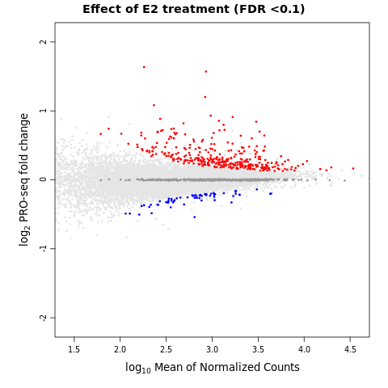

Figure 7: Effect of E2 treatment (FDR <0.1)

```r
save.image('231110_GATA3_pro_DEA_interaction1.1.Rdata')
```

**MA plot ((FDR <0.05)**

```r
# activated (use FDR 0.05)
activated = res2[res2$padj < 0.05 & !is.na(res2$padj) & res2$log2FoldChange > 0,]
unchanged = res1[!is.na(res1$padj) & res1$padj > 0.05 & abs(res1$log2FoldChange) < 0.01,]
unchanged$treatment = 0
activated$treatment = 1
df.deseq.effects.lattice = rbind(unchanged, activated)
out = matchit(treatment ~ baseMean, data = df.deseq.effects.lattice, method = "optimal", ratio = 1)
unchanged = df.deseq.effects.lattice[rownames(df.deseq.effects.lattice) %in% out$match.matrix,]
unchanged$treatment = "Matched to Up"
activated$treatment = "Up"
df.x = rbind(activated, unchanged)


# repressed  (use FDR 0.05)
repressed = res2[res2$padj < 0.05 & !is.na(res2$padj) & res2$log2FoldChange < 0,]
unchanged = res2[!is.na(res2$padj) & res2$padj > 0.05 & abs(res2$log2FoldChange) < 0.01,]
unchanged$treatment = 0
repressed$treatment = 1
df.deseq.effects.lattice = rbind(unchanged, repressed)
out = matchit(treatment ~ baseMean, data = df.deseq.effects.lattice, method = "optimal", ratio = 1)
unchanged = df.deseq.effects.lattice[rownames(df.deseq.effects.lattice) %in% out$match.matrix,]
unchanged$treatment = "Matched to Down"
repressed$treatment = "Down"
df.x = rbind(df.x, unchanged)
df.x = rbind(df.x, repressed)

#draw MA plot:
ma.df=df.x
ma.df[ma.df$treatment == "Matched to Up",]$treatment = "Unchanged"
ma.df[ma.df$treatment == "Matched to Down",]$treatment = "Unchanged"
# all.other genes
all.other=res2[!(rownames(res2) %in% rownames(ma.df)),]
all.other$treatment="all.other"
ma.df= rbind(ma.df, all.other)
ma.df$treatment <- factor(ma.df$treatment, levels=c("all.other", "Unchanged", "Up", "Down"))

# repressed: 28; activated: 283


ma.plot.lattice(ma.df, filename='FDR0.05_control_E2_vs_control_NoE2', title.main="Effect of E2 treatment (FDR <0.05)", col=c("grey90","grey60", "red", "blue"))
ma.plot.png.lattice(ma.df, filename='FDR0.05_control_E2_vs_control_NoE2', title.main="Effect of E2 treatment (FDR <0.05)", col=c("grey90","grey60", "red", "blue"))
```

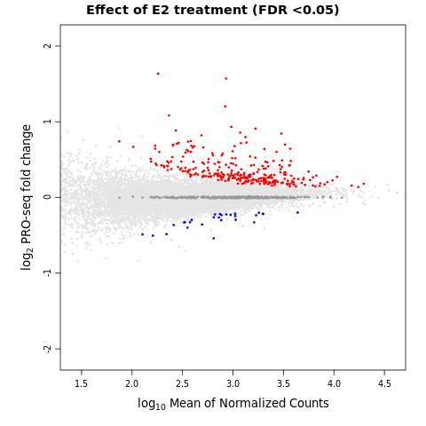

Figure 8: Effect of E2 treatment (FDR <0.05)

```r
save.image('231110_GATA3_pro_DEA_interaction1.2.Rdata')
```

## 3.7 bw plot for gene expression change under different condition

**+/- E2 effects**

```r
#inferred.coords=read.table('../PTA_ctrl/MCF7_GATA3_gene_annotations.bed', header =FALSE)
#counts.df = abs(get.raw.counts.interval(inferred.coords, "/home/FCAM/ssun/GATA3_ChIP_PRO_July2023/Pro_final/final_processed/seqoutbias_bw", file.prefix = "MCF"))

supp.condition1 =factor(rep(rep(c("E2","noE2"),each=3),2), levels=c("noE2","E2")) #noE2 is reference
supp.condition2=factor(rep(c("ctrl", "dTAG"), each = 6), levels=c("ctrl","dTAG")) #ctrl is reference
deseq.df = DESeqDataSetFromMatrix(counts.df,
                                  cbind.data.frame(supp.condition1, supp.condition2),
                                  ~ supp.condition1 + supp.condition2 + supp.condition1:supp.condition2)
dds = DESeq(deseq.df)

res_E2 = results(dds, contrast=c("supp.condition1","E2","noE2"))
sum(res_E2$padj < 0.1 & !is.na(res_E2$padj))
#392
sum(res_E2$padj < 0.05 & !is.na(res_E2$padj))
#311

############################### activated
activated = res_E2[res_E2$padj < 0.05 & !is.na(res_E2$padj) & res_E2$log2FoldChange > 0,] #283
activated$treatment = "Activated"

############################### repressed
repressed = res_E2[res_E2$padj < 0.05 & !is.na(res_E2$padj) & res_E2$log2FoldChange < 0,] #28
repressed$treatment = "Repressed"
```

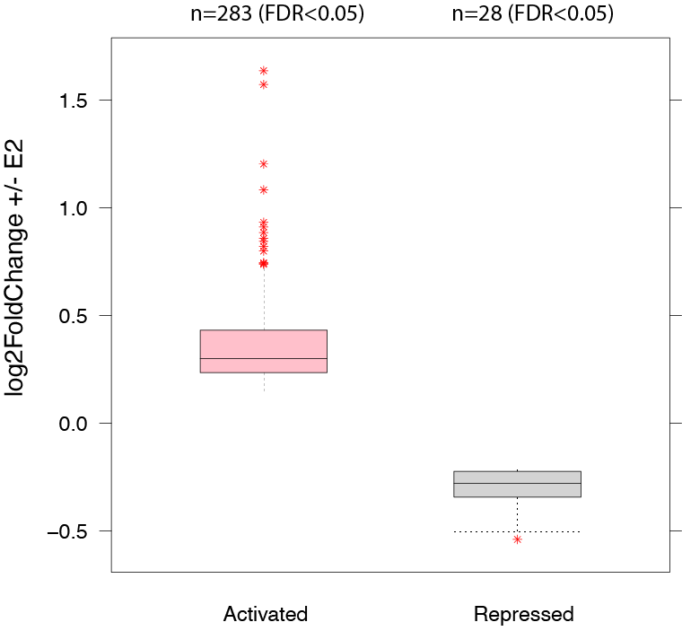

Figure 9: ER-regulated genes upon E2 treatment (FDR <0.05)

```r
# bw plot
bw.df.E2=as.data.frame(rbind(activated, repressed))
bw.df.E2$treatment=as.factor(bw.df.E2$treatment)


bw.plot.lattice(bw.df.E2, filename = '0.05_control_E2_vs_control_NoE2',
         title.main = "differentially expressed gene under E2 treatment (FDR=0.05)",
         fill.col = c("pink",  "light grey"))
```

**+/- dTAG effects on ER-activated genes**  
Taking the E2 activated genes (which confirmed by CDF that these are directly regulated by ER), extract these genes’ log2FoldChange value from DESeq2 results of “dTAGV1_E2” vs. “control_E2”.  
Need to first re-call DEseq2 to shift the reference level for ER. Make the reference level from noE2 to E2.

```r
#inferred.coords=read.table('../PTA_ctrl/MCF7_GATA3_gene_annotations.bed', header =FALSE)
#counts.df = abs(get.raw.counts.interval(inferred.coords, "/home/FCAM/ssun/GATA3_ChIP_PRO_July2023/Pro_final/final_processed/seqoutbias_bw", file.prefix = "MCF"))

supp.condition1 =factor(rep(rep(c("E2","noE2"),each=3),2), levels=c("E2","noE2")) # **E2 is the reference level
supp.condition2=factor(rep(c("ctrl", "dTAG"), each = 6), levels=c("ctrl","dTAG"))


deseq.df = DESeqDataSetFromMatrix(counts.df,
                                  cbind.data.frame(supp.condition1, supp.condition2),
                                  ~ supp.condition1 + supp.condition2 + supp.condition1:supp.condition2)
dds = DESeq(deseq.df)
resultsNames(dds)
#[1] "Intercept"
#[2] "supp.condition1_noE2_vs_E2"
#[3] "supp.condition2_dTAG_vs_ctrl"
#[4] "supp.condition1noE2.supp.condition2dTAG"

res_dTAG_E2 = results(dds, contrast=c("supp.condition2","dTAG","ctrl")) #comparing between dTAG vs ctrl under E2 treated reference
sum(res_dTAG_E2$padj < 0.1 & !is.na(res_dTAG_E2$padj))
#1965
```

```r
ER_activated =as.data.frame(activated)[,c(2,7)] #283
res_dTAG_E2=as.data.frame(results(dds, contrast=c("supp.condition2","dTAG","ctrl"))) #12952

ER_activated_dTAG = res_dTAG_E2[rownames(res_dTAG_E2) %in% rownames(ER_activated),] #283
sum(ER_activated_dTAG$padj < 0.1 & !is.na(ER_activated_dTAG$padj)) # 191
sum(ER_activated_dTAG$padj < 0.05 & !is.na(ER_activated_dTAG$padj)) # 176

############################### consider FDR (<0.05)
activated = ER_activated_dTAG[ER_activated_dTAG$padj < 0.05 & !is.na(ER_activated_dTAG$padj) & ER_activated_dTAG$log2FoldChange > 0,] #107
repressed= ER_activated_dTAG[ER_activated_dTAG$padj < 0.05 & !is.na(ER_activated_dTAG$padj) & ER_activated_dTAG$log2FoldChange < 0,] # 69

activated$treatment = "Activated*"
repressed$treatment = "Repressed*"

sig_ER_dTAG_df=as.data.frame(rbind(activated, repressed)) #176
```

1. ER-activated genes change expression status from active to repress upon GATA3 degradation

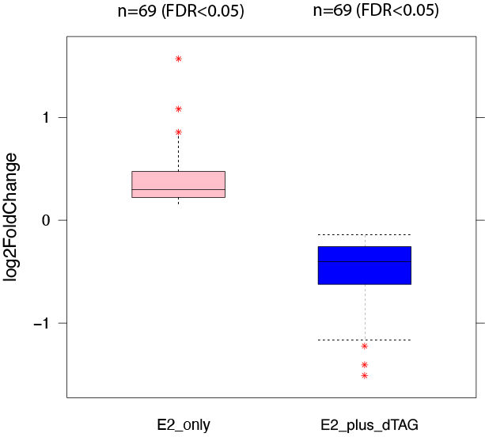

Figure 10: ER-regulated/activated genes convert expression status upon dTAG treatment (FDR <0.05)

```r
temp1=sig_ER_dTAG_df[sig_ER_dTAG_df$treatment=="Repressed*", ][,c(2,7)] #69
temp1$treatment="E2_plus_dTAG"
temp2=ER_activated[rownames(ER_activated) %in% rownames(temp1),] #69
temp2$treatment="E2_only"

# bw plot
shift_exp=as.data.frame(rbind(temp1,temp2))
shift_exp$treatment=as.factor(shift_exp$treatment)


bw.plot.lattice(shift_exp, filename = 'ER-activated_genes_upon_dTAG_change_status',
         title.main = "ER-activated genes shift expression status upon GATA3 degradation",
         fill.col = c("pink",  "blue"))
```

2. ER-activated genes increase activation upon GATA3 degradation

```r
temp3=sig_ER_dTAG_df[sig_ER_dTAG_df$treatment=="Activated*", ][,c(2,7)] #107
temp3$treatment="E2_plus_dTAG"
temp4=ER_activated[rownames(ER_activated) %in% rownames(temp3),] #107
temp4$treatment="E2_only"

change_exp=merge(temp3, temp4, by='row.names', all=TRUE) #107
change_exp$treatment = ifelse(change_exp$log2FoldChange.x > change_exp$log2FoldChange.y, "increase_activation" , "decrease_activation")
```

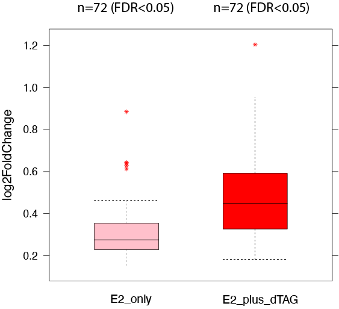

Figure 11: ER-regulated/activated genes increase activation upon dTAG treatment (FDR <0.05)

```r
inc_exp=change_exp[change_exp$treatment=="increase_activation",] #72

x=inc_exp[,2:3]
colnames(x)=c("log2FoldChange","treatment")
y=inc_exp[,4:5]
colnames(y)=c("log2FoldChange","treatment")
inc_exp2=as.data.frame(rbind(x,y))
inc_exp2$treatment=as.factor(inc_exp2$treatment)
# bw plot
bw.plot.lattice(inc_exp2, filename = 'ER-activated_genes_upon_dTAG_increase_activation',
         title.main = "ER-activated genes increase activation upon GATA3 degradation",
         fill.col = c("pink",  "red"))
```

3. ER-activated genes decrease activation upon GATA3 degradation

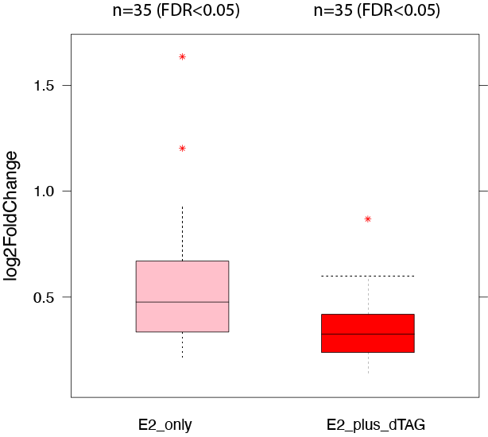

```r
dec_exp=change_exp[change_exp$treatment=="decrease_activation",] #35

x=dec_exp[,2:3]
colnames(x)=c("log2FoldChange","treatment")
y=dec_exp[,4:5]
colnames(y)=c("log2FoldChange","treatment")
dec_exp2=as.data.frame(rbind(x,y))
dec_exp2$treatment=as.factor(dec_exp2$treatment)
# bw plot
bw.plot.lattice(dec_exp2, filename = 'ER-activated_genes_upon_dTAG_decrease_activation',
         title.main = "ER-activated genes decrease activation upon GATA3 degradation",
         fill.col = c("pink",  "red"))
```

## 3.8 Coherence Check Call the interaction term directly from DESeq2 results (play around)

By changing the reference level in setting up conditions, or utilize the interaction term implied inside, one can easily call different DESeq2 results to address different questions

```r
#inferred.coords=read.table('../PTA_ctrl/MCF7_GATA3_gene_annotations.bed', header =FALSE)
#counts.df = abs(get.raw.counts.interval(inferred.coords, "/home/FCAM/ssun/GATA3_ChIP_PRO_July2023/Pro_final/final_processed/seqoutbias_bw", file.prefix = "MCF"))

supp.condition1 =factor(rep(rep(c("E2","noE2"),each=3),2), levels=c("noE2","E2")) #noE2 is reference
supp.condition1.1 =factor(rep(rep(c("E2","noE2"),each=3),2), levels=c("E2","noE2")) #E2 is reference
supp.condition2=factor(rep(c("ctrl", "dTAG"), each = 6), levels=c("ctrl","dTAG")) #ctrl is reference
supp.condition2.1=factor(rep(c("ctrl", "dTAG"), each = 6), levels=c("dTAG","ctrl")) #dTAG is reference

#noE2, nodTAG as reference
deseq.df = DESeqDataSetFromMatrix(counts.df,
                                  cbind.data.frame(supp.condition1, supp.condition2),
                                  ~ supp.condition1 + supp.condition2 + supp.condition1:supp.condition2)
dds = DESeq(deseq.df)

#E2 as reference
deseq.df1 = DESeqDataSetFromMatrix(counts.df,
                                  cbind.data.frame(supp.condition1.1, supp.condition2),
                                  ~ supp.condition1.1 + supp.condition2 + supp.condition1.1:supp.condition2)
dds1 = DESeq(deseq.df1)

#+dTAG as reference
deseq.df2 = DESeqDataSetFromMatrix(counts.df,
                                  cbind.data.frame(supp.condition1, supp.condition2.1),
                                  ~ supp.condition1 + supp.condition2.1 + supp.condition1:supp.condition2.1)
dds2 = DESeq(deseq.df2)
```

**the effect of dTAG treatment in ER activated condition**

```r
# the effect of dTAG treatment in ER activated condition
res1=results(dds, list(c("supp.condition2_dTAG_vs_ctrl", "supp.condition1E2.supp.condition2dTAG")))
#vs.
res1.1=results(dds1, contrast=c("supp.condition2","dTAG","ctrl"))
sum(res1$padj < 0.1 & !is.na(res1$padj)) #1963
sum(res1.1$padj < 0.1 & !is.na(res1.1$padj)) #1965

#this two call should be the same

temp=as.data.frame(cbind(res1, res1.1)[,c(2,8)])
colnames(temp)=c("interaction","E2_ref")
library(lattice)
png("comparing DESeq2 with interaction with different reference 1.png")
print(
  xyplot(E2_ref ~ interaction,data=temp,
       main="comparing DESeq2 with interaction with different reference")
)
dev.off()
```

**the effect of E2 treatment in GATA3-degraded (+dTAG) condition**

```r
# the effect of E2 treatment in GATA3-degraded (+dTAG) condition.
res2 = results(dds, list(c("supp.condition1_E2_vs_noE2","supp.condition1E2.supp.condition2dTAG")))
sum(res2$padj < 0.1 & !is.na(res2$padj)) #552


res2.1=results(dds2, contrast=c("supp.condition1","E2","noE2"))
sum(res2.1$padj < 0.1 & !is.na(res2.1$padj)) #543

#this two call should be the same

temp1=as.data.frame(cbind(res2, res2.1)[,c(2,8)])
colnames(temp1)=c("interaction","dTAG_ref")
library(lattice)
png("comparing DESeq2 with interaction with different reference 2.png")
print(
  xyplot(dTAG_ref ~ interaction,data=temp1,
       main="comparing DESeq2 with interaction with different reference")
)
dev.off()
```

**Is degrading GATA3 has different effect in E2 activated status and E2 inactivated status?**

```r
# Is degrading GATA3 has different effect in E2 activated status and E2 inactivated status? This is the interaction term. ---whether GATA3 depend on ER -- not much

res3 = results(dds, name="supp.condition1E2.supp.condition2dTAG")
sum(res3$padj < 0.1 & !is.na(res3$padj))
#110
sum(res3$padj < 0.05 & !is.na(res3$padj))
#49
sum(res3$padj < 0.01 & !is.na(res3$padj))
#19
```

## 3.9 CDF [ongoing]

**Determine if GATA3 directly regulate these ER-regulated/activated genes** (match to reverse…)

```r
load('231017_bw.Rdata')
rev_exp=temp1
rev_exp$treatment="reverse_expression"
rbind(rev_exp, change_exp)
```

```r
#inferred.coords=read.table('../PTA_ctrl/MCF7_GATA3_gene_annotations.bed', header =FALSE)
#counts.df = abs(get.raw.counts.interval(inferred.coords, "/home/FCAM/ssun/GATA3_ChIP_PRO_July2023/Pro_final/final_processed/seqoutbias_bw", file.prefix = "MCF"))

supp.condition1 =factor(rep(rep(c("E2","noE2"),each=3),2), levels=c("E2","noE2")) # **E2 is the reference level
supp.condition2=factor(rep(c("ctrl", "dTAG"), each = 6), levels=c("ctrl","dTAG"))


deseq.df = DESeqDataSetFromMatrix(counts.df,
                                  cbind.data.frame(supp.condition1, supp.condition2),
                                  ~ supp.condition1 + supp.condition2 + supp.condition1:supp.condition2)
dds = DESeq(deseq.df)
resultsNames(dds)
#[1] "Intercept"
#[2] "supp.condition1_noE2_vs_E2"
#[3] "supp.condition2_dTAG_vs_ctrl"
#[4] "supp.condition1noE2.supp.condition2dTAG"

res_dTAG_E2 = results(dds, contrast=c("supp.condition2","dTAG","ctrl")) #comparing between dTAG vs ctrl under E2 treated reference
sum(res_dTAG_E2$padj < 0.1 & !is.na(res_dTAG_E2$padj))
#1965
```

```r
ER_activated =as.data.frame(activated)[,c(2,7)] #277
res_dTAG_E2=as.data.frame(results(dds, contrast=c("supp.condition2","dTAG","ctrl"))) #13090

ER_activated_dTAG = res_dTAG_E2[rownames(res_dTAG_E2) %in% rownames(ER_activated),] #277
sum(ER_activated_dTAG$padj < 0.1 & !is.na(ER_activated_dTAG$padj)) # 185
sum(ER_activated_dTAG$padj < 0.05 & !is.na(ER_activated_dTAG$padj)) # 174

############################### consider FDR (<0.05)
activated = ER_activated_dTAG[ER_activated_dTAG$padj < 0.05 & !is.na(ER_activated_dTAG$padj) & ER_activated_dTAG$log2FoldChange > 0,] #107

unchanged


repressed= ER_activated_dTAG[ER_activated_dTAG$padj < 0.05 & !is.na(ER_activated_dTAG$padj) & ER_activated_dTAG$log2FoldChange < 0,] # 67

activated$treatment = "Activated*"
repressed$treatment = "Repressed*"

sig_ER_dTAG_df=as.data.frame(rbind(activated, repressed)) #174
```

```r
# activated
activated = res1[res1$padj < 0.01 & !is.na(res1$padj) & res1$log2FoldChange > 0,]
activated.strand = merge(cbind(tighten_summit_window(activated), "Activated"), inferred.coords, by.x = "gene", by.y = "V4")[,c(2, 3, 4, 1, 5, 10)]  # "chr" "start" "end" "gene" "Activated" "strand"
write.table(activated.strand, file = 'dTAGV1_NoE2_vs_control_NoE2_activated_genes.bed', quote = FALSE, row.names = FALSE, col.names = FALSE, sep = '\t')

# unchanged Matched to Activated
unchanged = res1[!is.na(res1$padj) & res1$padj > 0.1 & abs(res1$log2FoldChange) < 0.015,]

unchanged$treatment = 0
activated$treatment = 1
df.deseq.effects.lattice = rbind(unchanged, activated)
out = matchit(treatment ~ baseMean, data = df.deseq.effects.lattice, method = "optimal", ratio = 1)
        #Warning message:
        #Fewer control units than treated units; not all treated units will get a match.
        #unchanged has 655 genes, activated has 893 genes. Change log2FoldChange cutoff for unchanged gene (from 0.01) to 0.015, which increase the number of unchanged genes to 960. Now we have enough unchanged to match with the activated genes.

unchanged = df.deseq.effects.lattice[rownames(df.deseq.effects.lattice) %in% out$match.matrix,]
unchanged.strand = merge(cbind(tighten_summit_window(unchanged), "Matched to Activated"), inferred.coords, by.x = "gene", by.y = "V4")[,c(2, 3, 4, 1, 5, 10)]
write.table(unchanged.strand, file = 'dTAGV1_NoE2_vs_control_NoE2_activated_matched_genes.bed', quote = FALSE, row.names = FALSE, col.names = FALSE, sep = '\t')
unchanged$treatment = "Matched to Up"
activated$treatment = "Up"
df.x = rbind(activated, unchanged)


# repressed
repressed = res1[res1$padj < 0.01 & !is.na(res1$padj) & res1$log2FoldChange < 0,] #726
repressed.strand = merge(cbind(tighten_summit_window(repressed), "Repressed"), inferred.coords, by.x = "gene", by.y = "V4")[,c(2, 3, 4, 1, 5, 10)]
write.table(repressed.strand, file = 'dTAGV1_NoE2_vs_control_NoE2_repressed_genes.bed', quote = FALSE, row.names = FALSE, col.names = FALSE, sep = '\t')


# unchanged Matched to repressed
unchanged = res1[!is.na(res1$padj) & res1$padj > 0.1 & abs(res1$log2FoldChange) < 0.015,]
unchanged$treatment = 0
repressed$treatment = 1
df.deseq.effects.lattice = rbind(unchanged, repressed)
out = matchit(treatment ~ baseMean, data = df.deseq.effects.lattice, method = "optimal", ratio = 1)


unchanged = df.deseq.effects.lattice[rownames(df.deseq.effects.lattice) %in% out$match.matrix,]
unchanged.strand = merge(cbind(tighten_summit_window(unchanged), "Matched to Repressed"), inferred.coords, by.x = "gene", by.y = "V4")[,c(2, 3, 4, 1, 5, 10)]
write.table(unchanged.strand, file = 'dTAGV1_NoE2_vs_control_NoE2_repressed_matched_genes.bed', quote = FALSE, row.names = FALSE, col.names = FALSE, sep = '\t')
unchanged$treatment = "Matched to Down"
repressed$treatment = "Down"
df.x = rbind(df.x, unchanged)
df.x = rbind(df.x, repressed)
```

## 3.10 Questions: how GATA3 contributes to ER regulated genes? [ongoing]

Some possibilities:  
If GATA3 directly regulate ER-activated genes:

GATA3 it self or its co-activator is activating some genes, so lose GATA3 will cause gene decrease activation/lose activation(become repress); GATA3 is able to recruit some co-activator

GATA3 indirectly regulate ER-activated genes:

# 4 Integrate with ChIP [SEE ChIP_analysis]

The above activated, repressed, and matched files in bed format are going to be integrated with our ChIP exp to draw CDF plots and determine functional ChIP peaks.

# 5 Un-mapped reads in PRO-seq

**Are these un-mapped reads short sequences?**  
We first use `samtools` to convert concordantly mapped reads (`-f 0x2`) and un-mapped(`-F 0X2`) reads to .fastq format, then use `fastqc` to check sequence quality (length distribution,…).  
other useful command: `samtools flagstat`

**PE1**

```r
#cd /labs/Guertin/siyu/Sathyan_GATA3_PRO_final/final_processed/bam

# get mapped/unmapped reads and convert to fastq
module load samtools/1.16.1
for i in *.bam
do
  name=$(echo $i | awk -F".bam" '{print $1}')
  echo $name
  samtools fastq -f 0x42 $i > ${name}_mapped.fastq # read mapped in proper pair;  first in pair
  echo "complete converting mapped reads to fastq"
  samtools fastq -F 0x82 $i > ${name}_unmapped.fastq # the opposite of (read mapped in proper pair;  second in pair)
  echo "complete converting un-mapped reads to fastq"
done

module load samtools/1.16.1
for i in *.bam
do
  name=$(echo $i | awk -F".bam" '{print $1}')
  echo $name
  samtools fasta -F 0x82 $i > ${name}_unmapped.fasta
  echo "complete converting un-mapped reads to fasta"
done

# samtools flag 0x42 (first in pair) are only reporting half of the reads (only PE1);
# it is half of the reads compared to using flag 0X3 (reads in pair)

# fastqc
module load fastqc
for i in *_mapped.fastq
do
  echo $i
  fastqc $i
  echo "fastqc complete"
done

for i in *_unmapped.fastq
do
  echo $i
  fastqc $i
  echo "fastqc complete"
done
```

coherence check

```r
#MCF7_dTAGGATAClone522_30min_control_E2_rep1.bam
module load samtools/1.16.1
samtools fastq MCF7_dTAGGATAClone522_30min_control_E2_rep1.bam > MCF7_dTAGGATAClone522_30min_control_E2_rep1.fastq
#[M::bam2fq_mainloop] discarded 0 singletons
#[M::bam2fq_mainloop] processed 41668696 reads
wc -l MCF7_dTAGGATAClone522_30min_control_E2_rep1.fastq #166674784

wc -l MCF7_dTAGGATAClone522_30min_control_E2_rep1_mapped.fastq #61265800
wc -l MCF7_dTAGGATAClone522_30min_control_E2_rep1_unmapped.fastq #22071592

# (61265800 + 22071592) * 2 = 166674784
```

**PE2**

```r
#cd /labs/Guertin/siyu/Sathyan_GATA3_PRO_final/final_processed/bam

# get mapped/unmapped reads and convert to fastq
module load samtools/1.16.1
module load fastqc
for i in ../*.bam
do
  name=$(echo $i | awk -F"/" '{print $2}'| awk -F".bam" '{print $1}')
  echo $name
  samtools fastq -f 0x82 $i > ${name}_mapped_PE2.fastq # read mapped in proper pair;  second in pair
  echo "complete converting mapped reads to fastq"
  samtools fastq -F 0x42 $i > ${name}_unmapped_PE2.fastq # the opposite of (read mapped in proper pair;  first in pair)
  echo "complete converting un-mapped reads to fastq"
done

# fastqc
for i in *_mapped_PE2.fastq
do
  echo $i
  fastqc $i
  echo "fastqc complete"
done

for i in *_unmapped_PE2.fastq
do
  echo $i
  fastqc $i
  echo "fastqc complete"
done


module load samtools/1.16.1
for i in ../*.bam
do
  name=$(echo $i | awk -F"/" '{print $2}'| awk -F".bam" '{print $1}')
  echo $name
  samtools fasta -F 0x42 $i > ${name}_unmapped_PE2.fasta
  echo "complete converting un-mapped reads to fasta"
done
```

coherence check

```r
#MCF7_dTAGGATAClone522_30min_control_E2_rep1.bam
module load samtools/1.16.1
samtools fastq MCF7_dTAGGATAClone522_30min_control_E2_rep1.bam > MCF7_dTAGGATAClone522_30min_control_E2_rep1.fastq
#[M::bam2fq_mainloop] discarded 0 singletons
#[M::bam2fq_mainloop] processed 41668696 reads
wc -l MCF7_dTAGGATAClone522_30min_control_E2_rep1.fastq #166674784

wc -l MCF7_dTAGGATAClone522_30min_control_E2_rep1_mapped.fastq #61265800
wc -l MCF7_dTAGGATAClone522_30min_control_E2_rep1_unmapped.fastq #22071592

# (61265800 + 22071592) * 2 = 166674784
```

**fastqc results** shows that most sequences length are expected. There are short sequences exists but not dominant.

Sequence Length Distribution: for mapped reads (PE1): sequence length mostly enriched for 39bp (warning by fastqc); for unmapped reads: sequence length mostly enriched for 39bp (warning by fastqc).  
This module will raise a warning if all sequences are not the same length.

**fastqc results** also show many overrepresented sequences in the unmapped sequences to be RPI4 and Illumina small RNA adapter 2.

```r
# mapped reads:
cat MCF7_dTAGGATAClone522_30min_control_NoE2_rep1_mapped.fastq | grep TGGAATTCTCGGGTGCCAAGG | wc -l # 0
cat MCF7_dTAGGATAClone522_30min_control_NoE2_rep1_mapped.fastq | grep GATCGTCGGACTGTAGAACTCTGAAC | wc -l # 0

#unmapped reads:
cat MCF7_dTAGGATAClone522_30min_control_NoE2_rep1_unmapped.fastq | grep TGGAATTCTCGGGTGCCAAGG | wc -l # 0
#cat MCF7_dTAGGATAClone522_30min_control_NoE2_rep1_unmapped.fastq | grep CCTTGGCACCCGAGAATTCCA | wc -l # 0 #reverse complement

cat MCF7_dTAGGATAClone522_30min_control_NoE2_rep1_unmapped.fastq | grep GATCGTCGGACTGTAGAACTCTGAAC | wc -l # 1418
```

I confirmed that in the raw fastq file, the two adapter sequences are indeed in the PE1 and PE2 reads before `cutadapt`, and trimmed after `cutadapt`.  
In normal situation, the sequences from raw fastq will have features of: PE1 reads with 5’ adapter, PE2 reads with 3’ adapter; However, I found some unexpected cases where **some PE1 sequences somehow has reverse compliment of 3’ adapter**, and **some PE2 sequences has reversed 5’ adapter**. `cutadapt` will not trim these off and these sequences are carried on to next steps.

```r
cat /labs/Guertin/siyu/Sathyan_GATA3_PRO_final/final_raw/MCF7_dTAGGATAClone522_30min_control_E2_rep1_PE1_final.fastq | head -n 20000000 > MCF7_dTAGGATAClone522_30min_control_E2_rep1_PE1_final_test.fastq
#PE1 adapter
cat MCF7_dTAGGATAClone522_30min_control_E2_rep1_PE1_final_test.fastq | grep TGGAATTCTCGGGTGCCAAGG | wc -l #1987892
#cat MCF7_dTAGGATAClone522_30min_control_E2_rep1_PE1_final_test.fastq | grep CCTTGGCACCCGAGAATTCCA | wc -l #0. rv 5' adp
#cat MCF7_dTAGGATAClone522_30min_control_E2_rep1_PE1_final_test.fastq | grep GATCGTCGGACTGTAGAACTCTGAAC | wc -l #0 3' adp
#cat MCF7_dTAGGATAClone522_30min_control_E2_rep1_PE1_final_test.fastq | grep GTTCAGAGTTCTACAGTCCGACGATC | wc -l #143 rv 3' adp

cat /labs/Guertin/siyu/Sathyan_GATA3_PRO_final/final_raw/MCF7_dTAGGATAClone522_30min_control_E2_rep1_PE2_final.fastq | head -n 20000000 > MCF7_dTAGGATAClone522_30min_control_E2_rep1_PE2_final_test.fastq
#PE2 adapter
cat MCF7_dTAGGATAClone522_30min_control_E2_rep1_PE2_final_test.fastq | grep GATCGTCGGACTGTAGAACTCTGAAC | wc -l #1260034
#cat MCF7_dTAGGATAClone522_30min_control_E2_rep1_PE2_final_test.fastq | grep GTTCAGAGTTCTACAGTCCGACGATC | wc -l #0 rv 3' adp
#cat MCF7_dTAGGATAClone522_30min_control_E2_rep1_PE2_final_test.fastq | grep TGGAATTCTCGGGTGCCAAGG | wc -l #0 5' adp
#cat MCF7_dTAGGATAClone522_30min_control_E2_rep1_PE2_final_test.fastq | grep CCTTGGCACCCGAGAATTCCA | wc -l #73980. rv 5' adp


# we have used  -m $((UMI_length+2)) and $((UMI_length+10)) to filter any sequences that are shorter than 10
module load cutadapt/3.5
cutadapt -m 10 -O 1 -a TGGAATTCTCGGGTGCCAAGG MCF7_dTAGGATAClone522_30min_control_E2_rep1_PE1_final_test.fastq -o MCF7_dTAGGATAClone522_30min_control_E2_rep1_PE1_test_noadap.fastq --too-short-output test_PE1_short.fastq
cutadapt -m 18 -O 1 -a GATCGTCGGACTGTAGAACTCTGAAC MCF7_dTAGGATAClone522_30min_control_E2_rep1_PE2_final_test.fastq -o MCF7_dTAGGATAClone522_30min_control_E2_rep1_PE2_test_noadap.fastq --too-short-output test_PE2_short.fastq

cat MCF7_dTAGGATAClone522_30min_control_E2_rep1_PE1_test_noadap.fastq | grep TGGAATTCTCGGGTGCCAAGG | wc -l #0
#cat MCF7_dTAGGATAClone522_30min_control_E2_rep1_PE1_test_noadap.fastq | grep GTTCAGAGTTCTACAGTCCGACGATC | wc -l #86 rv 3' adp
cat MCF7_dTAGGATAClone522_30min_control_E2_rep1_PE2_test_noadap.fastq | grep GATCGTCGGACTGTAGAACTCTGAAC | wc -l
#cat MCF7_dTAGGATAClone522_30min_control_E2_rep1_PE2_test_noadap.fastq | grep CCTTGGCACCCGAGAATTCCA | wc -l #73979 rv 5' adp
```

## 5.1 two-step cutadapt try out

```r
file_PE1=/labs/Guertin/siyu/Sathyan_GATA3_PRO_final/final_raw/MCF7_dTAGGATAClone522_30min_control_E2_rep1_PE1_final.fastq
file_PE2=/labs/Guertin/siyu/Sathyan_GATA3_PRO_final/final_raw/MCF7_dTAGGATAClone522_30min_control_E2_rep1_PE2_final.fastq
# 1st cutadapt: we have used  -m $((UMI_length+2)) and $((UMI_length+10)) to filter any sequences that are shorter than 10; -O sets the minimum overlap parameters
module load cutadapt/3.5
cutadapt -m 10 -O 1 -a TGGAATTCTCGGGTGCCAAGG $file_PE1 -o PE1_test_noadap1.fastq --too-short-output test_PE1_short1.fastq > PE1_test_cutadapt1.txt
cutadapt -m 18 -O 1 -a GATCGTCGGACTGTAGAACTCTGAAC $file_PE2 -o PE2_test_noadap1.fastq --too-short-output test_PE2_short1.fastq > PE2_test_cutadapt1.txt

# 2nd cutadapt
cutadapt -m 10 -O 10 -a TGGAATTCTCGGGTGCCAAGG PE1_test_noadap1.fastq -o PE1_test_noadap2.fastq --too-short-output test_PE1_short2.fastq > PE1_test_cutadapt2.txt
cutadapt -m 18 -O 10 -a GATCGTCGGACTGTAGAACTCTGAAC PE2_test_noadap1.fastq -o PE2_test_noadap2.fastq --too-short-output test_PE2_short2.fastq > PE2_test_cutadapt2.txt


wc -l PE1_test_noadap1.fastq | awk '{print $1/4}' #29473968
wc -l PE2_test_noadap1.fastq | awk '{print $1/4}' #33116654
wc -l PE1_test_noadap2.fastq | awk '{print $1/4}' #28845586
wc -l PE2_test_noadap2.fastq | awk '{print $1/4}' #33115759

cutadapt -m 10 -O 10 --rc -a TGGAATTCTCGGGTGCCAAGG PE1_test_noadap1.fastq -o PE1_test_noadap3.fastq --too-short-output test_PE1_short3.fastq > PE1_test_cutadapt3.txt
cutadapt -m 18 -O 10 --rc -a GATCGTCGGACTGTAGAACTCTGAAC PE2_test_noadap1.fastq -o PE2_test_noadap3.fastq --too-short-output test_PE2_short3.fastq > PE2_test_cutadapt3.txt

wc -l PE1_test_noadap3.fastq | awk '{print $1/4}' #28845563
wc -l PE2_test_noadap3.fastq | awk '{print $1/4}' #33115713

for i in *noadap2.fastq
do
 fastqc $i
 echo $i
 echo "fastqc complete"
done

for i in *noadap3.fastq
do
 fastqc $i
 echo $i
 echo "fastqc complete"
done
```

```r
#! /bin/sh

#SBATCH --job-name=pro_processing_two_cutadapt.sh
#SBATCH -N 1
#SBATCH -n 1
#SBATCH -c 32
#SBATCH -p himem
#SBATCH --qos=himem
#SBATCH --mem=68G
#SBATCH --mail-type=ALL
#SBATCH --mail-user=ssun@uchc.edu
#SBATCH -o pro_processing_two_cutadapt.sh_%j.out
#SBATCH -e pro_processing_two_cutadapt.sh_%j.err

hostname
set -e
export PATH=$PATH:/home/FCAM/ssun/packages/://home/FCAM/ssun/scripts
#directory=/home/FCAM/ssun/GATA3_ChIP_PRO_July2023/Pro_final/final_processed/unmap/cutadapt/

module load cutadapt/3.5
module load seqtk/1.3
#seqOutBias=/home/FCAM/mguertin/software/seqOutBias
#fqdedup=/home/FCAM/mguertin/ZNF143_PRO/fqdedup-1.0.0/target/release/fqdedup
#flash=/home/FCAM/mguertin/software/flash
module load fastq-pair/1.0
module load samtools/1.16.1
module load genometools/1.5.10
module load ucsc_genome/2012.05.22
module load rust
module load bowtie2
module load bedtools

sizes=/home/FCAM/ssun/Genome_pro/hg38.chrom.sizes
annotation_prefix=/home/FCAM/ssun/Annotation/Annotation_110/Homo_sapiens.GRCh38.110
UMI_length=8
read_size=39
cores=32
genome=/home/FCAM/ssun/Genome_pro/hg38.fa
genome_index=/home/FCAM/ssun/Genome_pro/hg38_bt2/hg38
prealign_rdna_index=/home/FCAM/ssun/Genome_pro/human_rDNA_bt2/human_rDNA
tallymer=/home/FCAM/ssun/Genome_pro/seqOutbias_hg38/hg38.tal_${read_size}.gtTxt.gz
table=/home/FCAM/ssun/Genome_pro/seqOutbias_hg38/hg38_${read_size}.4.2.2.tbl


#echo 'removing dual adapter ligations and calculating the fraction of adapter/adapters in' $name
echo 'removing short RNA insertions'
seqtk seq -L $((UMI_length+10)) PE1_test_noadap2.fastq > PE1_test_noadap2_trimmed.fastq # removes inserts that are shorter than 10 bases

echo 'removing PCR duplicates'
fqdedup -i PE1_test_noadap2_trimmed.fastq -o PE1_test_dedup.fastq #remove PCR duplicates
PE1_noAdapter=$(wc -l PE1_test_dedup.fastq | awk '{print $1/4}') #this variable is a near-optimal table size value for fastq_pair
fastq_pair -t $PE1_noAdapter PE1_test_dedup.fastq PE2_test_noadap2.fastq #pair FASTQ files


echo 'calculating and plotting RNA insert sizes'
# measure RNA degradation by searching for overlap between paired end reads with flash and plotting the resultant histogram output with insert_size.R
flash -q --compress-prog=gzip --suffix=gz PE1_test_dedup.fastq.paired.fq \
        PE2_test_noadap2.fastq.paired.fq -o test
insert_size.R test.hist ${UMI_length}


echo 'trimming off the UMI'
# removes the UMI and reverse complements from paired end reads
seqtk trimfq -b ${UMI_length} PE1_test_dedup.fastq | seqtk seq -r - > PE1_processed.fastq
seqtk trimfq -e ${UMI_length} PE2_test_noadap2.fastq | seqtk seq -r - > PE2_processed.fastq


echo 'aligning to rDNA and removing aligned reads'
    bowtie2 -p $((cores-2)) -x $prealign_rdna_index -U PE1_processed.fastq 2>test_bowtie2_rDNA.log | \
        samtools sort -n - | samtools fastq -f 0x4 - > PE1.rDNA.fastq
# removes PE2-aligned reads with a rDNA-aligned mate
reads=$(wc -l PE1.rDNA.fastq | awk '{print $1/4}')
fastq_pair -t $reads PE1.rDNA.fastq PE2_processed.fastq


echo 'aligning to the genome'
bowtie2 -p $((cores-2)) --maxins 1000 -x $genome_index --rf -1 PE1.rDNA.fastq.paired.fq \
        -2 PE2_processed.fastq.paired.fq 2>test_bowtie2.log | samtools view -b - | \
        samtools sort - -o test.bam # align to the genome;  --rf flag is to account for the fact that we reverse complemented both reads; samtools convert the file to BAM and sort the reads.


#calculate the total number of rDNA-aligned reads
PE1_prior_rDNA=$(wc -l PE1_processed.fastq | awk '{print $1/4}')
PE1_post_rDNA=$(wc -l PE1.rDNA.fastq | awk '{print $1/4}')
total_rDNA=$(echo "$(($PE1_prior_rDNA-$PE1_post_rDNA))")
#calculate the total that concordantly align to hg38 and/or rDNA
concordant_pe1=$(samtools view -c -f 0x42 test.bam)
total=$(echo "$(($concordant_pe1+$total_rDNA))")
#rDNA alignment rate
rDNA_alignment=$(echo "scale=2 ; $total_rDNA / $total" | bc)
echo -e "$rDNA_alignment\t$name\t0.10\trDNA Alignment Rate" >> QC_metrics.txt

#Mappability rate (expect an alignment rate above 80% for high quality libraries)
map_pe1=$(samtools view -c -f 0x42 test.bam)
pre_alignment=$(wc -l PE1.rDNA.fastq.paired.fq | awk '{print $1/4}')
alignment_rate=$(echo "scale=2 ; $map_pe1 / $pre_alignment" | bc)
echo -e "$alignment_rate\t$name\t0.80\tAlignment Rate" >> QC_metrics.txt
```

```r
#test.bam
module load samtools/1.16.1
samtools fastq -F 0x82 test.bam > test_unmapped_PE1.fastq
samtools fastq -F 0x42 test.bam > test_unmapped_PE2.fastq
samtools fastq -f 0x82 test.bam > test_mapped_PE2.fastq
samtools fastq -f 0x42 test.bam > test_mapped_PE1.fastq

module load fastqc
for i in *.fastq
do
  echo $i
  fastqc $i
  echo "fastqc complete"
done
```

fastq results shows that, by perform a second cutadapt with minumum overlap of 10bp, we no longer see overrepresented 5’ adapters in mapped reads; but the PE2 unmapped reads still contains some 21bp 5’adapter. I suspect these adapter reads are come from the unexpected case where raw fastq PE2 reads has rc of 5’ adapter.

```r
#set5
#manually remove reversed opposite adapter
cutadapt -m 10 -O 15 -a GTTCAGAGTTCTACAGTCCGACGATC ../PE1_test_noadap2.fastq -o PE1_test_noadap5.fastq --too-short-output test_PE1_short5.fastq > PE1_test_cutadapt5.txt #0.1% reads with reversed 3' adapter at PE1
cutadapt -m 18 -O 15 -a CCTTGGCACCCGAGAATTCCA ../PE2_test_noadap2.fastq -o PE2_test_noadap5.fastq --too-short-output test_PE2_short5.fastq > PE2_test_cutadapt5.txt #3.3% reads with reversed 5' adapter at PE2


# align to genome

#echo 'removing dual adapter ligations and calculating the fraction of adapter/adapters in' $name
echo 'removing short RNA insertions'
seqtk seq -L $((UMI_length+10)) PE1_test_noadap5.fastq > PE1_test_noadap5_trimmed.fastq # removes inserts that are shorter than 10 bases

echo 'removing PCR duplicates'
fqdedup -i PE1_test_noadap5_trimmed.fastq -o PE1_test_dedup.fastq #remove PCR duplicates
PE1_noAdapter=$(wc -l PE1_test_dedup.fastq | awk '{print $1/4}') #this variable is a near-optimal table size value for fastq_pair
fastq_pair -t $PE1_noAdapter PE1_test_dedup.fastq PE2_test_noadap5.fastq #pair FASTQ files


echo 'calculating and plotting RNA insert sizes'
# measure RNA degradation by searching for overlap between paired end reads with flash and plotting the resultant histogram output with insert_size.R
flash -q --compress-prog=gzip --suffix=gz PE1_test_dedup.fastq.paired.fq \
        PE2_test_noadap5.fastq.paired.fq -o test
insert_size.R test.hist ${UMI_length}


echo 'trimming off the UMI'
# removes the UMI and reverse complements from paired end reads
seqtk trimfq -b ${UMI_length} PE1_test_dedup.fastq | seqtk seq -r - > PE1_processed.fastq
seqtk trimfq -e ${UMI_length} PE2_test_noadap5.fastq | seqtk seq -r - > PE2_processed.fastq


echo 'aligning to rDNA and removing aligned reads'
    bowtie2 -p $((cores-2)) -x $prealign_rdna_index -U PE1_processed.fastq 2>test_bowtie2_rDNA.log | \
        samtools sort -n - | samtools fastq -f 0x4 - > PE1.rDNA.fastq
# removes PE2-aligned reads with a rDNA-aligned mate
reads=$(wc -l PE1.rDNA.fastq | awk '{print $1/4}')
fastq_pair -t $reads PE1.rDNA.fastq PE2_processed.fastq


echo 'aligning to the genome'
bowtie2 -p $((cores-2)) --maxins 1000 -x $genome_index --rf -1 PE1.rDNA.fastq.paired.fq \
        -2 PE2_processed.fastq.paired.fq 2>test_bowtie2.log | samtools view -b - | \
        samtools sort - -o test.bam # align to the genome;  --rf flag is to account for the fact that we reverse complemented both reads; samtools convert the file to BAM and sort the reads.


#calculate the total number of rDNA-aligned reads
PE1_prior_rDNA=$(wc -l PE1_processed.fastq | awk '{print $1/4}')
PE1_post_rDNA=$(wc -l PE1.rDNA.fastq | awk '{print $1/4}')
total_rDNA=$(echo "$(($PE1_prior_rDNA-$PE1_post_rDNA))")
#calculate the total that concordantly align to hg38 and/or rDNA
concordant_pe1=$(samtools view -c -f 0x42 test.bam)
total=$(echo "$(($concordant_pe1+$total_rDNA))")
#rDNA alignment rate
rDNA_alignment=$(echo "scale=2 ; $total_rDNA / $total" | bc)
echo -e "$rDNA_alignment\t$name\t0.10\trDNA Alignment Rate" >> QC_metrics.txt

#Mappability rate (expect an alignment rate above 80% for high quality libraries)
map_pe1=$(samtools view -c -f 0x42 test.bam)
pre_alignment=$(wc -l PE1.rDNA.fastq.paired.fq | awk '{print $1/4}')
alignment_rate=$(echo "scale=2 ; $map_pe1 / $pre_alignment" | bc)
echo -e "$alignment_rate\t$name\t0.80\tAlignment Rate" >> QC_metrics.txt


#test.bam
module load samtools/1.16.1
samtools fastq -F 0x82 test.bam > test_unmapped_PE1.fastq
samtools fastq -F 0x42 test.bam > test_unmapped_PE2.fastq
samtools fastq -f 0x82 test.bam > test_mapped_PE2.fastq
samtools fastq -f 0x42 test.bam > test_mapped_PE1.fastq

module load fastqc
for i in *map*.fastq
do
  echo $i
  fastqc $i
  echo "fastqc complete"
done
```

There are overrepresented RNA primer index, also trim these

```r
#set6

module load cutadapt/3.5
# manually remove RPI adapter(reversed)
cutadapt -m 10 -O 18 -a CTCGGGTGCCAAGGAACTCCAGTCAC ../set5/PE1_test_noadap5.fastq -o PE1_test_noadap6.fastq --too-short-output test_PE1_short6.fastq > PE1_test_cutadapt6.txt #0.3% reads with RPI adapter(reversed)

# align to genome

#echo 'removing dual adapter ligations and calculating the fraction of adapter/adapters in' $name
echo 'removing short RNA insertions'
seqtk seq -L $((UMI_length+10)) PE1_test_noadap6.fastq > PE1_test_noadap6_trimmed.fastq # removes inserts that are shorter than 10 bases

echo 'removing PCR duplicates'
fqdedup -i PE1_test_noadap6_trimmed.fastq -o PE1_test_dedup.fastq #remove PCR duplicates
PE1_noAdapter=$(wc -l PE1_test_dedup.fastq | awk '{print $1/4}') #this variable is a near-optimal table size value for fastq_pair
fastq_pair -t $PE1_noAdapter PE1_test_dedup.fastq ../set5/PE2_test_noadap5.fastq #pair FASTQ files


echo 'calculating and plotting RNA insert sizes'
# measure RNA degradation by searching for overlap between paired end reads with flash and plotting the resultant histogram output with insert_size.R
flash -q --compress-prog=gzip --suffix=gz PE1_test_dedup.fastq.paired.fq \
        ../set5/PE2_test_noadap5.fastq.paired.fq -o test
insert_size.R test.hist ${UMI_length}


echo 'trimming off the UMI'
# removes the UMI and reverse complements from paired end reads
seqtk trimfq -b ${UMI_length} PE1_test_dedup.fastq | seqtk seq -r - > PE1_processed.fastq
seqtk trimfq -e ${UMI_length} ../set5/PE2_test_noadap5.fastq | seqtk seq -r - > PE2_processed.fastq


echo 'aligning to rDNA and removing aligned reads'
    bowtie2 -p $((cores-2)) -x $prealign_rdna_index -U PE1_processed.fastq 2>test_bowtie2_rDNA.log | \
        samtools sort -n - | samtools fastq -f 0x4 - > PE1.rDNA.fastq
# removes PE2-aligned reads with a rDNA-aligned mate
reads=$(wc -l PE1.rDNA.fastq | awk '{print $1/4}')
fastq_pair -t $reads PE1.rDNA.fastq PE2_processed.fastq


echo 'aligning to the genome'
bowtie2 -p $((cores-2)) --maxins 1000 -x $genome_index --rf -1 PE1.rDNA.fastq.paired.fq \
        -2 PE2_processed.fastq.paired.fq 2>test_bowtie2.log | samtools view -b - | \
        samtools sort - -o test.bam # align to the genome;  --rf flag is to account for the fact that we reverse complemented both reads; samtools convert the file to BAM and sort the reads.


#calculate the total number of rDNA-aligned reads
PE1_prior_rDNA=$(wc -l PE1_processed.fastq | awk '{print $1/4}')
PE1_post_rDNA=$(wc -l PE1.rDNA.fastq | awk '{print $1/4}')
total_rDNA=$(echo "$(($PE1_prior_rDNA-$PE1_post_rDNA))")
#calculate the total that concordantly align to hg38 and/or rDNA
concordant_pe1=$(samtools view -c -f 0x42 test.bam)
total=$(echo "$(($concordant_pe1+$total_rDNA))")
#rDNA alignment rate
rDNA_alignment=$(echo "scale=2 ; $total_rDNA / $total" | bc)
echo -e "$rDNA_alignment\t$name\t0.10\trDNA Alignment Rate" >> QC_metrics.txt

#Mappability rate (expect an alignment rate above 80% for high quality libraries)
map_pe1=$(samtools view -c -f 0x42 test.bam)
pre_alignment=$(wc -l PE1.rDNA.fastq.paired.fq | awk '{print $1/4}')
alignment_rate=$(echo "scale=2 ; $map_pe1 / $pre_alignment" | bc)
echo -e "$alignment_rate\t$name\t0.80\tAlignment Rate" >> QC_metrics.txt


#test.bam
module load samtools/1.16.1
samtools fastq -F 0x82 test.bam > test_unmapped_PE1.fastq
samtools fastq -F 0x42 test.bam > test_unmapped_PE2.fastq
samtools fastq -f 0x82 test.bam > test_mapped_PE2.fastq
samtools fastq -f 0x42 test.bam > test_mapped_PE1.fastq

module load fastqc
for i in *map*.fastq
do
  echo $i
  fastqc $i
  echo "fastqc complete"
done
```

```r
module load samtools/1.16.1
map_pe2=$(samtools view -c -f 0x82 test.bam)
pre_alignment=$(wc -l PE2_processed.fastq.paired.fq | awk '{print $1/4}')
alignment_rate=$(echo "scale=2 ; $map_pe2 / $pre_alignment" | bc)

#aligning PE2 gives same 74% alignment rate --expected
```

**unmapped reads**

```r
20162145 reads; of these:
  20162145 (100.00%) were paired; of these:
    5070062 (25.15%) aligned concordantly 0 times
    9970755 (49.45%) aligned concordantly exactly 1 time
    5121328 (25.40%) aligned concordantly >1 times
    ----
    5070062 pairs aligned concordantly 0 times; of these:
      264187 (5.21%) aligned discordantly 1 time
    ----
    4805875 pairs aligned 0 times concordantly or discordantly; of these:
      9611750 mates make up the pairs; of these:
        4883292 (50.81%) aligned 0 times
        2490603 (25.91%) aligned exactly 1 time
        2237855 (23.28%) aligned >1 times
87.89% overall alignment rate

#set6
module load samtools/1.16.1
samtools view -c test.bam  #40324290
samtools view -b -F 2 test.bam > test_nca.bam

# 1) discordantly aligned as pairs (994847*2)
samtools view -c -f 161 -F 28 test_nca.bam #PE2                #203679
samtools view -c -f 81 -F 44 test_nca.bam #PE1 reverse strand

samtools view -c -f 145  -F 44 test_nca.bam #PE2 reverse strand. #427148
samtools view -c -f 97  -F 28 test_nca.bam #PE1

samtools view -c -f 177 -F 12 test_nca.bam #PE2 reverse strand   #364020
samtools view -c -f 113 -F 12 test_nca.bam #PE1 reverse strand

# 2) read 1 in one locus & read2 in completely different locus (153520*2) --split reads
samtools view -c -f 129 -F 60 test_nca.bam #PE2.        #153520
samtools view -c -f 65 -F 60 test_nca.bam #PE1.


# 3) one mate aligned, the other mate not aligned (2960098*2)
samtools view -c -f 165 -F 24 test_nca.bam #PE2 un-map               #1230983
samtools view -c -f 89 -F 36 test_nca.bam #PE1 reverse but map.

samtools view -c -f 153 -F 36 test_nca.bam #PE2 reverse but map.    # 308753
samtools view -c -f 101 -F 24 test_nca.bam #PE1 un-map

samtools view -c -f 137 -F 52 test_nca.bam #PE2 map non-reverse           #157420
samtools view -c -f 69 -F 56 test_nca.bam #PE1 un-map.

samtools view -c -f 133 -F 56 test_nca.bam #PE2 un-map              # 1262942
samtools view -c -f 73 -F 52 test_nca.bam #PE1. map non-reverse


# 4) not align at all
samtools view -c -f 141 -F 48 test_nca.bam #PE2 un-map            #961597
samtools view -c -f 77 -F 48 test_nca.bam #PE1 un-map
```

```r
#BLAST
module load R/4.1.2
R

library("lattice")
bar=read.csv('MCF7_4adapt_unmapped_reads_bar.csv')
bar$supp<- factor(bar$supp, levels = c("concordantly_aligned", "discordant_orientation", "split_reads"          , "only_one_mate_align", "not_align_at_all"))

pdf('bar_MCF7_dTAGGATAClone522_30min_control_E2_rep1_unmapped.pdf', width=5,height=6)
print(barchart(fraction ~ supp,
         data = bar,
         #groups = enriched_motif,
         #stack = TRUE,
         auto.key=list(space="right"),
         scales = list(x = list(rot = 45)),
         ylim=c(0,1),
         ylab = "fraction of reads",
         xlab = "reads categories",
         #par.settings = my.settings)
))
dev.off()

bar=read.csv('compare_unmapped_reads_bar.csv')
bar$supp<- factor(bar$supp, levels = c("concordantly_aligned", "discordant_orientation", "split_reads"          , "only_one_mate_align", "not_align_at_all"))

pdf('bar_compare_unmapped.pdf', width=8,height=6)
print(barchart(fraction ~ supp,
         data = bar,
         groups = lib,
         #stack = TRUE,
         auto.key=list(space="right"),
         scales = list(x = list(rot = 45)),
         ylim=c(0,1),
         ylab = "fraction of reads",
         xlab = "reads categories",
         #par.settings = my.settings)
))
dev.off()
```

```r
#set6
# PE1 unmap, but PE2 map (test_setA)
samtools fastq -f 153 -F 36 test_nca.bam > PE2_test1.fastq #PE2 reverse but map.
samtools fastq -f 101 -F 24 test_nca.bam > PE1_test1.fastq #PE1 un-map

samtools fastq -f 137 -F 52 test_nca.bam > PE2_test2.fastq #PE2 map non-reverse
samtools fastq -f 69 -F 56 test_nca.bam > PE1_test2.fastq #PE1 un-map.

cat PE1_test1.fastq PE1_test2.fastq > test_setA_unmap_PE1.fastq
cat PE2_test1.fastq PE2_test2.fastq > test_setA_map_PE2.fastq

# PE1 map, but PE2 unmap (test_setB)
samtools fastq -f 165 -F 24 test_nca.bam > PE2_test3.fastq #PE2 un-map
samtools fastq -f 89 -F 36 test_nca.bam > PE1_test3.fastq #PE1 reverse but map.

samtools fastq -f 133 -F 56 test_nca.bam > PE2_test4.fastq #PE2 un-map
samtools fastq -f 73 -F 52 test_nca.bam > PE1_test4.fastq #PE1. map non-reverse

cat PE1_test3.fastq PE1_test4.fastq > test_setB_map_PE1.fastq
cat PE2_test3.fastq PE2_test4.fastq > test_setB_unmap_PE2.fastq

# PE1 unmap, and PE2 unmap (test_setC)
samtools fastq -f 141 -F 48 test_nca.bam > test_setC_unmap_PE2.fastq #PE2 un-map
samtools fastq -f 77 -F 48 test_nca.bam > test_setC_unmap_PE1.fastq #PE1 un-map

module load fastqc
for i in *set*.fastq
do
  echo $i
  fastqc $i
  echo "fastqc complete"
done
```

get read length from file

```r
for i in *set*.fastq
do
 name=$(echo $i | awk -F".fastq" '{print $1}')
 echo $name
 #convert from fastq to fasta
 sed -n '1~4s/^@/>/p;2~4p' $i > ${name}.fasta
 #get read length
 cat ${name}.fasta | awk '$0 ~ ">" {print c;c=0} $0 !~ ">" {c+=length($0);} END { print c; }' | sed '/^$/d' | sort | uniq -c | awk '{print $1,$2}' > ${name}_read_length.txt
done
```

## 5.2 BLAST to nt

**BLAST on web** To run BLAST on NCBI web, we need to first divide large sequence file (.fasta) to smaller sequence file due to web’s size limitation on input files.

```r
awk -v size=25000 -v pre=30min_control_NoE2_rep1_unmapped -v pad=5 '
   /^>/ { n++; if (n % size == 1) { close(fname); fname = sprintf("%s.%0" pad "d", pre, n ) } }
   { print >> fname }
' MCF7_dTAGGATAClone522_30min_control_NoE2_rep1_unmapped.fasta

awk -v size=2000 -v pre=test1 -v pad=5 '
   /^>/ { n++; if (n % size == 1) { close(fname); fname = sprintf("%s.%0" pad "d", pre, n ) } }
   { print >> fname }
' 30min_control_NoE2_rep1_unmapped.00001
```

**Standalone BLAST Setup** Install BLAST+ locally following instructions here: https://www.ncbi.nlm.nih.gov/books/NBK52640/  
NCBI database:https://ftp.ncbi.nlm.nih.gov/blast/db/

```r
# https://ftp.ncbi.nlm.nih.gov/blast/executables/LATEST/
# ncbi-blast-2.14.1+-x64-macosx.tar
export PATH=$PATH:$HOME/ncbi-blast-2.14.1+/bin
echo $PATH
mkdir blastdb
cd blastdb
#cd /Users/ssun/blast/ncbi-blast-2.14.1+/blastdb
perl ../bin/update_blastdb.pl --passive --decompress nt #nt.gz nucleotide sequence database
```

**Blast un-mapped reads locally**  
1) Blast to full nt database  
To save running time, first we need to divide the large .fa sequence file to smaller file contains 500 sequences (i.e., test2-500.00001); running multiple files at the same time give us 2k to 10k random sequence blast output to make some conclusions.

MCF7 libraries:

```r
#500 blastn set1 (test2.00001)
blastn -task blastn -query /Users/ssun/Desktop/unmapped_fasta/split/split2/test2-500.00001 -db nt -out /Users/ssun/Desktop/unmapped_fasta/blastn_MCF7_nt.all/Blast_nt.all_test2-500.00001.txt
blastn -task blastn -query /Users/ssun/Desktop/unmapped_fasta/split/split2/test2-500.00001 -db nt -out /Users/ssun/Desktop/unmapped_fasta/blastn_MCF7_nt.all/Blast_nt.all_test2-500.00001_OR.txt -outfmt 18 #Organism Report
```

HEK libraries:

```r
awk -v size=2000 -v pre=HEK -v pad=5 '
   /^>/ { n++; if (n % size == 1) { close(fname); fname = sprintf("%s.%0" pad "d", pre, n ) } }
   { print >> fname }
' HEK_CloneZD29_30min_control_rep2_unmapped.fasta

#try blast the entire nt database with 2000 random peaks (around 4 hrs for megablast) per file
cd /Users/ssun/blast/ncbi-blast-2.14.1+/blastdb
blastn -task blastn -query /Users/ssun/Desktop/unmapped_fasta/split_HEK/HEK.00001 -db nt -out /Users/ssun/Desktop/unmapped_fasta/blastn_HEK_nt.all/Blast_nt.all_HEK.00001.txt

blastn -task blastn -query /Users/ssun/Desktop/unmapped_fasta/split_HEK/HEK.00001 -db nt -out /Users/ssun/Desktop/unmapped_fasta/blastn_HEK_nt.all/Blast_nt.all_HEK.00001.txt -outfmt 18
```

### 5.2.1 BLASTn results

```r
#cat Blast_nt.all_test2-500.00001.txt Blast_nt.all_test2-500.00501.txt Blast_nt.all_test2-500.01501.txt Blast_nt.all_test2.test2-500.01001.txt > Blast_MCF7_nt.all_test2.00001_2000.txt

#cat Blast_MCF7_nt.all_test2.00001_2000.txt| grep "No hits found" | wc -l
     #205

#sed -n "/\s${line}/w target_${line}.txt" targets.txt
#awk '/keyword/' RS="\n\n" ORS="\n\n" input.txt
#awk '/homo sapiens/' RS="Query=" ORS="" Blast_MCF7_nt.all_test2.00001_2000.txt > Blast_MCF7_nt.all_test2.00001_2000_human.txt #[took too long to run--terminate]
#cat Blast_MCF7_nt.all_test2.00001_2000_human.txt | grep "Effective search space used" | wc -l

#awk '/bacteri/' RS="Query=" ORS="" Blast_MCF7_nt.all_test2.00001_2000.txt > Blast_MCF7_nt.all_test2.00001_2000_bacteri.txt
#cat Blast_MCF7_nt.all_test2.00001_2000_bacteri.txt | grep "Effective search space used" | wc -l

#coherence check
cat *OR.txt | grep "Tax BLAST report" | wc -l #10000
```

```r
#Split the file into multiple files at every occurrence of the pattern "Tax BLAST report" .
awk '/Tax BLAST report/{x="F"++i;}{print > x;}' file2
grep -rl "Homo sapiens" "/usr/share"


# print the file with
cat *Blast_nt.all*.txt > blastn_MCF7_10k.txt
cat blastn_MCF7_10k.txt | grep "Query=" | wc -l
cat blastn_MCF7_10k.txt | grep "No hit found" | wc -l


cat *OR.txt > blastn_MCF7_10k_OR.txt
cat blastn_MCF7_10k_OR.txt | grep "Query=" | wc -l #10000
awk '/homo sapiens/' RS="Tax BLAST report" ORS="" blastn_MCF7_10k_OR.txt > blastn_MCF7_10k_OR_human.txt
cat blastn_MCF7_10k_OR_human.txt | grep "Query=" | wc -l #389

awk '/homo sapiens/' RS="Tax BLAST report" ORS="" blastn_MCF7_10k_OR.txt > blastn_MCF7_10k_OR_human.txt
cat blastn_MCF7_10k_OR_human.txt | grep "Query=" | wc -l
```

## 5.3 BLAST to other databases

2. Blast to env_nt.00

```r
tar xfz env_nt.tar
blastn -query MCF7_dTAGGATAClone522_30min_control_E2_rep1_unmapped.fasta -db env_nt.00 -out MCF7_dTAGGATAClone522_30min_control_E2_rep1_unmapped.html -html

cat MCF7_dTAGGATAClone522_30min_control_E2_rep1_unmapped.html | grep subunit > MCF7_dTAGGATAClone522_30min_control_E2_rep1_unmapp_blast_env_nt.00.summary.txt
```

“subunit ribosomal RNA gene, partial sequence”.

3. Blast to mito.tar.gz

```r
tar xfz mito.tar.gz
blastn -query MCF7_dTAGGATAClone522_30min_control_E2_rep1_unmapped.fasta -db mito -out mito_MCF7_dTAGGATAClone522_30min_control_E2_rep1_unmapped.html -html
```

no hit for mitochondrial DNA.

4. Blast to nt_prok.00.tar.gz

```r
tar xfz nt_prok.00.tar.gz
blastn -query MCF7_dTAGGATAClone522_30min_control_E2_rep1_unmapped.fasta -db nt_prok.00 -out nt_prok.00_MCF7_dTAGGATAClone522_30min_control_E2_rep1_unmapped.html -html
```

Beta proteobacterium

5. Blast to nt_viruses.00.tar

```r
tar xfz nt_viruses.00.tar
blastn -query MCF7_dTAGGATAClone522_30min_control_E2_rep1_unmapped.fasta -db nt_viruses.00 -out nt_viruses.00_MCF7_dTAGGATAClone522_30min_control_E2_rep1_unmapped.html -html
```

No hit

## 5.4 Why many “unmapped reads” can BLAST to human genome?

SAM Flags can extract reads with different features (reference: https://broadinstitute.github.io/picard/explain-flags.html):  
**Concordantly aligned reads**: (-f 0x2) R1 (forward)——-> expected mapping distance <——- R2 (reverse)  
note that in our pipeline, we have reversed R1 and R2, and we set the maximum mapping distance between them as 1000bp (–maxins 1000). **discordantly aligned reads**: these reads can align to human genome, but with 1) unexpected mapping distance; 2) unexpected read orientation; or 3) read 1/2 align to completely different locus. **not aligned reads**: 1) reads with one mate aligned, the other not; 2) both mate not align to genome.

```r
#bowtie2 alignment report for MCF7_dTAGGATAClone522_30min_control_NoE2_rep1
23110803 reads; of these:
  23110803 (100.00%) were paired; of these:
    7290845 (31.55%) aligned concordantly 0 times.
    10029068 (43.40%) aligned concordantly exactly 1 time       # aligned concordantly
    5790890 (25.06%) aligned concordantly >1 times              # aligned concordantly
    ----
    7290845 pairs aligned concordantly 0 times; of these:
      293772 (4.03%) aligned discordantly 1 time                 # aligned discordantly
    ----
    6997073 pairs aligned 0 times concordantly or discordantly; of these:
      13994146 mates make up the pairs; of these:
        8518974 (60.88%) aligned 0 times                          # not aligned at all
        2762655 (19.74%) aligned exactly 1 time.   # aligned 0 times concordantly or discordantly
        2712517 (19.38%) aligned >1 times          # aligned 0 times concordantly or discordantly
81.57% overall alignment rate

overall alignment rate (81.57%): (10029068*2+5790890*2+293772*2+(2762655+2712517))/(23110803*2)
```

```r
samtools view -c MCF7_dTAGGATAClone522_30min_control_NoE2_rep1.bam
46221606 # double of 23110803, make sense because these 46221606 are single reads, but 23110803 are paired.

samtools view -c -f 0x42 MCF7_dTAGGATAClone522_30min_control_NoE2_rep1.bam
15819958 # = 10029068+5790890 (concordantly aligned as pairs)

samtools view -c -F 0x82 MCF7_dTAGGATAClone522_30min_control_NoE2_rep1.bam  # not concordantly aligned (PE1)
7290845 # contains all reads that are 1) discordantly aligned and 2) not aligned
samtools view -c -F 0x42 MCF7_dTAGGATAClone522_30min_control_NoE2_rep1.bam # not concordantly aligned (PE2)
7290845
samtools view -c -F 2 MCF7_dTAGGATAClone522_30min_control_NoE2_rep1.bam  # not concordantly aligned
14581690
```

“Unmapped reads” (use -F 0X2) is actually **All non-concordantly aligned reads**: (total - concordantly aligned) 23110803*2-(10029068*2+5790890*2) == 7290845*2, these reads include:  
1) both reads aligned, but read1 or read2 or both reads has unexpected orientation;  
2) both reads aligned, but read 1 align to one locus & read2 align to completely different locus;  
3) one mate aligned, the other mate not aligned;  
4) both reads not align at all .

**MCF7**

```r
samtools view -b -F 2 ../MCF7_dTAGGATAClone522_30min_control_NoE2_rep1.bam >MCF7_dTAGGATAClone522_30min_control_NoE2_rep1_nca.bam

# 1) discordantly aligned as pairs (1061107*2)
samtools view -f 161 -F 28 MCF7_dTAGGATAClone522_30min_control_NoE2_rep1_nca.bam #PE2                #220179
samtools view -c -f 81 -F 44 MCF7_dTAGGATAClone522_30min_control_NoE2_rep1_nca.bam #PE1 reverse strand  #220179

samtools view -c -f 145  -F 44 MCF7_dTAGGATAClone522_30min_control_NoE2_rep1_nca.bam #PE2 reverse strand. #456826
samtools view -c -f 97  -F 28 MCF7_dTAGGATAClone522_30min_control_NoE2_rep1_nca.bam #PE1                  #456826

samtools view -c -f 177 -F 12 MCF7_dTAGGATAClone522_30min_control_NoE2_rep1_nca.bam #PE2 reverse strand   # 384102
samtools view -c -f 113 -F 12 MCF7_dTAGGATAClone522_30min_control_NoE2_rep1_nca.bam #PE1 reverse strand

# 2) read 1 in one locus & read2 in completely different locus (161935*2) --split reads
samtools view -f 129 -F 60 MCF7_dTAGGATAClone522_30min_control_NoE2_rep1_nca.bam #PE2.        #161935
samtools view -c -f 65 -F 60 MCF7_dTAGGATAClone522_30min_control_NoE2_rep1_nca.bam #PE1.         #161935


# 3) one mate aligned, the other mate not aligned (3616632*2)
samtools view -c -f 165 -F 24 MCF7_dTAGGATAClone522_30min_control_NoE2_rep1_nca.bam #PE2 un-map               # 1424033
samtools view -c -f 89 -F 36 MCF7_dTAGGATAClone522_30min_control_NoE2_rep1_nca.bam #PE1 reverse but map.      # 1424033

samtools view -c -f 153 -F 36 MCF7_dTAGGATAClone522_30min_control_NoE2_rep1_nca.bam #PE2 reverse but map.    # 489522
samtools view -c -f 101 -F 24 MCF7_dTAGGATAClone522_30min_control_NoE2_rep1_nca.bam #PE1 un-map              # 489522

samtools view -c -f 137 -F 52 MCF7_dTAGGATAClone522_30min_control_NoE2_rep1_nca.bam #PE2 map non-reverse           #207603
samtools view -c -f 69 -F 56 MCF7_dTAGGATAClone522_30min_control_NoE2_rep1_nca.bam #PE1 un-map.                    #207603

samtools view -c -f 133 -F 56 MCF7_dTAGGATAClone522_30min_control_NoE2_rep1_nca.bam #PE2 un-map              #1495474
samtools view -c -f 73 -F 52 MCF7_dTAGGATAClone522_30min_control_NoE2_rep1_nca.bam #PE1. map non-reverse     #1495474

#these I did not found
#samtools view -c -F 0x2 -f 157 MCF7_dTAGGATAClone522_30min_control_NoE2_rep1.bam #PE2 un-map reverse
#samtools view -c -F 0x2 -f  MCF7_dTAGGATAClone522_30min_control_NoE2_rep1.bam #PE1 un-map

#samtools view -c -F 0x2 -f  MCF7_dTAGGATAClone522_30min_control_NoE2_rep1.bam #PE2 un-map
#samtools view -c -F 0x2 -f 93 MCF7_dTAGGATAClone522_30min_control_NoE2_rep1.bam #PE1 un-map reverse

#samtools view -c -F 0x2 -f  MCF7_dTAGGATAClone522_30min_control_NoE2_rep1.bam #PE2 un-map reverse
#samtools view -c -F 0x2 -f  MCF7_dTAGGATAClone522_30min_control_NoE2_rep1.bam #PE1 un-map reverse


# 4) not align at all
samtools view -c -f 141 -F 48 MCF7_dTAGGATAClone522_30min_control_NoE2_rep1_nca.bam #PE2 un-map            #2451171
samtools view -c -f 77 -F 48 MCF7_dTAGGATAClone522_30min_control_NoE2_rep1_nca.bam #PE1 un-map             #2451171


#samtools view -c -f 4 MCF7_dTAGGATAClone522_30min_control_NoE2_rep1_nca.bam #don't know why, but these reads has no mate
#8518974 #(18.43% overall not aligned reads)
```

**HEK**

```r
samtools view -c /labs/Guertin/siyu/HEK_CloneZD29_30min_control_rep2.bam #51883566/2=25941783
samtools view -b -F 2 /labs/Guertin/siyu/HEK_CloneZD29_30min_control_rep2.bam >HEK_CloneZD29_30min_control_rep2_nca.bam

# 1) discordantly aligned as pairs (1019772*2)
samtools view -c -f 161 -F 28 HEK_CloneZD29_30min_control_rep2_nca.bam #PE2                #194307
samtools view -c -f 81 -F 44 HEK_CloneZD29_30min_control_rep2_nca.bam #PE1 reverse strand

samtools view -c -f 145  -F 44 HEK_CloneZD29_30min_control_rep2_nca.bam #PE2 reverse strand. #390244
samtools view -c -f 97  -F 28 HEK_CloneZD29_30min_control_rep2_nca.bam #PE1

samtools view -c -f 177 -F 12 HEK_CloneZD29_30min_control_rep2_nca.bam #PE2 reverse strand   # 315598
samtools view -c -f 113 -F 12 HEK_CloneZD29_30min_control_rep2_nca.bam #PE1 reverse strand

# 2) read 1 in one locus & read2 in completely different locus (119623*2) --split reads
samtools view -c -f 129 -F 60 HEK_CloneZD29_30min_control_rep2_nca.bam #PE2.        #119623
samtools view -c -f 65 -F 60 HEK_CloneZD29_30min_control_rep2_nca.bam #PE1.


# 3) one mate aligned, the other mate not aligned (2889566*2)
samtools view -c -f 165 -F 24 HEK_CloneZD29_30min_control_rep2_nca.bam #PE2 un-map               # 1231697
samtools view -c -f 89 -F 36 HEK_CloneZD29_30min_control_rep2_nca.bam #PE1 reverse but map.

samtools view -c -f 153 -F 36 HEK_CloneZD29_30min_control_rep2_nca.bam #PE2 reverse but map.    # 253886
samtools view -c -f 101 -F 24 HEK_CloneZD29_30min_control_rep2_nca.bam #PE1 un-map

samtools view -c -f 137 -F 52 HEK_CloneZD29_30min_control_rep2_nca.bam #PE2 map non-reverse           #144496
samtools view -c -f 69 -F 56 HEK_CloneZD29_30min_control_rep2_nca.bam #PE1 un-map.

samtools view -c -f 133 -F 56 HEK_CloneZD29_30min_control_rep2_nca.bam #PE2 un-map              # 1259487
samtools view -c -f 73 -F 52 HEK_CloneZD29_30min_control_rep2_nca.bam #PE1. map non-reverse


# 4) not align at all
samtools view -c -f 141 -F 48 HEK_CloneZD29_30min_control_rep2_nca.bam #PE2 un-map            #727664
samtools view -c -f 77 -F 48 HEK_CloneZD29_30min_control_rep2_nca.bam #PE1 un-map
```

```r
module load R/4.1.2
R

library("lattice")
bar=read.csv('unmapped_reads_bar.csv')
bar$supp<- factor(bar$supp, levels = c("concordantly_aligned", "discordant_orientation", "split_reads"          , "only_one_mate_align", "not_align_at_all"))

pdf('bar_MCF7_dTAGGATAClone522_30min_control_NoE2_rep1_unmapped.pdf', width=5,height=6)
print(barchart(percentage ~ supp,
         data = bar,
         #groups = enriched_motif,
         #stack = TRUE,
         auto.key=list(space="right"),
         scales = list(x = list(rot = 45)),
         ylim=c(0,1),
         ylab = "percentage of reads",
         xlab = "reads categories",
         #par.settings = my.settings)
))
dev.off()

bar2=read.csv('HEK_unmapped_reads_bar.csv')
bar2$supp<- factor(bar2$supp, levels = c("concordantly_aligned", "discordant_orientation", "split_reads"          , "only_one_mate_align", "not_align_at_all"))

pdf('bar_HEK_CloneZD29_30min_control_rep2_unmapped.pdf', width=5,height=6)
print(barchart(percentage ~ supp,
         data = bar2,
         #groups = enriched_motif,
         #stack = TRUE,
         auto.key=list(space="right"),
         scales = list(x = list(rot = 45)),
         ylim=c(0,1),
         ylab = "percentage of reads",
         xlab = "reads categories",
         #par.settings = my.settings)
))
dev.off()
```

### 5.4.1 Coherence check

Check if SAM Flag called unmapped reads are indeed not align to genome (bowtie2).

```r
module load samtools/1.16.1
dir=/labs/Guertin/siyu/Sathyan_GATA3_PRO_final/final_processed/bam/Analysis/
# PE1 unmap, but PE2 map (MCF7_setA)
samtools fastq -f 153 -F 36 ${dir}MCF7_dTAGGATAClone522_30min_control_NoE2_rep1_nca.bam > PE2_test1.fastq #PE2 reverse but map.# 489522
samtools fastq -f 101 -F 24 ${dir}MCF7_dTAGGATAClone522_30min_control_NoE2_rep1_nca.bam > PE1_test1.fastq #PE1 un-map  # 489522

samtools fastq -f 137 -F 52 ${dir}MCF7_dTAGGATAClone522_30min_control_NoE2_rep1_nca.bam > PE2_test2.fastq #PE2 map non-reverse     #207603
samtools fastq -f 69 -F 56 ${dir}MCF7_dTAGGATAClone522_30min_control_NoE2_rep1_nca.bam > PE1_test2.fastq #PE1 un-map.

cat PE1_test1.fastq PE1_test2.fastq > MCF7_setA_unmap_PE1.fastq
cat PE2_test1.fastq PE2_test2.fastq > MCF7_setA_map_PE2.fastq

# PE1 map, but PE2 unmap (MCF7_setB)
samtools fastq -f 165 -F 24 ${dir}MCF7_dTAGGATAClone522_30min_control_NoE2_rep1_nca.bam > PE2_test3.fastq #PE2 un-map               # 1424033
samtools fastq -f 89 -F 36 ${dir}MCF7_dTAGGATAClone522_30min_control_NoE2_rep1_nca.bam > PE1_test3.fastq #PE1 reverse but map.

samtools fastq -f 133 -F 56 ${dir}MCF7_dTAGGATAClone522_30min_control_NoE2_rep1_nca.bam > PE2_test4.fastq #PE2 un-map              #1495474
samtools fastq -f 73 -F 52 ${dir}MCF7_dTAGGATAClone522_30min_control_NoE2_rep1_nca.bam > PE1_test4.fastq #PE1. map non-reverse

cat PE1_test3.fastq PE1_test4.fastq > MCF7_setB_map_PE1.fastq
cat PE2_test3.fastq PE2_test4.fastq > MCF7_setB_unmap_PE2.fastq

# PE1 unmap, and PE2 unmap (MCF7_setC)
samtools fastq -f 141 -F 48 ${dir}MCF7_dTAGGATAClone522_30min_control_NoE2_rep1_nca.bam > MCF7_setC_unmap_PE2.fastq #PE2 un-map            #2451171
samtools fastq -f 77 -F 48 ${dir}MCF7_dTAGGATAClone522_30min_control_NoE2_rep1_nca.bam > MCF7_setC_unmap_PE1.fastq #PE1 un-map
```

Now we have three sets of reads: PE1 unmap but PE2 map (MCF7_setA); PE1 map, but PE2 unmap (MCF7_setB); and PE1 unmap, and PE2 unmap (MCF7_setC).  
We align them to genome with single-end mode.

```r
# Bowtie2 alignment -U
# Comma-separated list of files containing unpaired reads to be aligned
module load samtools/1.16.1
module load bowtie2/2.5.0
cores=32
genome_index=/home/FCAM/ssun/Genome_pro/hg38_bt2/hg38

for i in *set*.fastq
do
#bowtie2 -p 10 --sensitive --no-mixed -t -x my_genome -U my_File.fq.gz -S my_output.sam
  name=$(echo $i | awk -F".fastq" '{print $1}')
  bowtie2 -p $((cores-2)) --maxins 1000 -x $genome_index -U $i 2>${name}_bowtie2.log | samtools view -b - | \
        samtools sort - -o ${name}.bam
done

# check if there are duplicated sequences in each set -- no
for i in *set*.fastq
do
  grep "@" $i| sort | uniq -d
  echo $i
done
```

### 5.4.2 FASTQC

FASTQC on reads that not aligned at all (MCF7_setC); FASTQC on reads that one mate align but its pair not (MCF7_setA and MCF7_setB).

```r
module load fastqc
for i in *set*.fastq
do
  echo $i
  fastqc $i
  echo "fastqc complete"
done
```

### 5.4.3 BLAST

```r
#module load samtools/1.16.1
#dir=/labs/Guertin/siyu/Sathyan_GATA3_PRO_final/final_processed/bam/Analysis/
#samtools fasta -f 141 -F 48 ${dir}MCF7_dTAGGATAClone522_30min_control_NoE2_rep1_nca.bam > MCF7_setC_unmap_PE2.fasta #PE2 un-map
#samtools fasta -f 77 -F 48 ${dir}MCF7_dTAGGATAClone522_30min_control_NoE2_rep1_nca.bam > MCF7_setC_unmap_PE1.fasta
awk -v size=500 -v pre=MCF7_setC_unmap_PE1 -v pad=5 '
   /^>/ { n++; if (n % size == 1) { close(fname); fname = sprintf("%s.%0" pad "d", pre, n ) } }
   { print >> fname }
' MCF7_setC_unmap_PE1.fasta

cd /Users/ssun/blast/ncbi-blast-2.14.1+/blastdb
blastn -task blastn -query /Users/ssun/Desktop/not_aligned_atall/MCF7_setC_unmap_PE1.00001 -db nt -out /Users/ssun/Desktop/not_aligned_atall/blastn_ntall_e0.01/Blast_nt.all_MCF7_setC_unmap_PE1.00001_OR.txt -outfmt 18 -evalue 0.01
# Blast hits with E-value smaller than 0.01 can still be considered as good hit for homology matches.

blastn -task blastn -query /Users/ssun/Desktop/not_aligned_atall/MCF7_setC_unmap_PE1.00501 -db nt -out /Users/ssun/Desktop/not_aligned_atall/blastn_ntall_e0.01/Blast_nt.all_MCF7_setC_unmap_PE1.00501_OR.txt -outfmt 18 -evalue 0.01

blastn -task blastn -query /Users/ssun/Desktop/not_aligned_atall/MCF7_setC_unmap_PE1.01001 -db nt -out /Users/ssun/Desktop/not_aligned_atall/blastn_ntall_e0.01/Blast_nt.all_MCF7_setC_unmap_PE1.01001_OR.txt -outfmt 18 -evalue 0.01

blastn -task blastn -query /Users/ssun/Desktop/not_aligned_atall/MCF7_setC_unmap_PE1.01501 -db nt -out /Users/ssun/Desktop/not_aligned_atall/blastn_ntall_e0.01/Blast_nt.all_MCF7_setC_unmap_PE1.01501_OR.txt -outfmt 18 -evalue 0.01
```

```r
# HEK control for blastn
# module load samtools/1.16.1
# samtools view -b -F 2 /labs/Guertin/siyu/HEK_CloneZD29_30min_control_rep2.bam >HEK_CloneZD29_30min_control_rep2_nca.bam
# PE1 unmap, but PE2 map (HEK_setA)
samtools fastq -f 153 -F 36 HEK_CloneZD29_30min_control_rep2_nca.bam > PE2_test1.fastq #PE2 reverse but map.# 489522
samtools fastq -f 101 -F 24 HEK_CloneZD29_30min_control_rep2_nca.bam > PE1_test1.fastq #PE1 un-map  # 489522

samtools fastq -f 137 -F 52 HEK_CloneZD29_30min_control_rep2_nca.bam > PE2_test2.fastq #PE2 map non-reverse     #207603
samtools fastq -f 69 -F 56 HEK_CloneZD29_30min_control_rep2_nca.bam > PE1_test2.fastq #PE1 un-map.

cat PE1_test1.fastq PE1_test2.fastq > HEK_setA_unmap_PE1.fastq
cat PE2_test1.fastq PE2_test2.fastq > HEK_setA_map_PE2.fastq

# PE1 map, but PE2 unmap (HEK_setB)
samtools fastq -f 165 -F 24 HEK_CloneZD29_30min_control_rep2_nca.bam > PE2_test3.fastq #PE2 un-map               # 1424033
samtools fastq -f 89 -F 36 HEK_CloneZD29_30min_control_rep2_nca.bam > PE1_test3.fastq #PE1 reverse but map.

samtools fastq -f 133 -F 56 HEK_CloneZD29_30min_control_rep2_nca.bam > PE2_test4.fastq #PE2 un-map              #1495474
samtools fastq -f 73 -F 52 HEK_CloneZD29_30min_control_rep2_nca.bam > PE1_test4.fastq #PE1. map non-reverse

cat PE1_test3.fastq PE1_test4.fastq > HEK_setB_map_PE1.fastq
cat PE2_test3.fastq PE2_test4.fastq > HEK_setB_unmap_PE2.fastq

# PE1 unmap, and PE2 unmap (HEK_notalignatall)
samtools fasta -f 141 -F 48 HEK_CloneZD29_30min_control_rep2_nca.bam > HEK_setC_unmap_PE2.fasta #PE2 un-map
samtools fasta -f 77 -F 48 HEK_CloneZD29_30min_control_rep2_nca.bam > HEK_setC_unmap_PE1.fasta #PE1 un-map

awk -v size=500 -v pre=HEK_setC_unmap_PE1 -v pad=5 '
   /^>/ { n++; if (n % size == 1) { close(fname); fname = sprintf("%s.%0" pad "d", pre, n ) } }
   { print >> fname }
' HEK_setC_unmap_PE1.fasta

cd /Users/ssun/blast/ncbi-blast-2.14.1+/blastdb
blastn -task blastn -query /Users/ssun/Desktop/not_aligned_atall/HEK_setC_unmap_PE1.00001 -db nt -out /Users/ssun/Desktop/not_aligned_atall/blastn_ntall_e0.01/Blast_nt.all_HEK_setC_unmap_PE1.00001_OR.txt -outfmt 18 -evalue 0.01
# Blast hits with E-value smaller than 0.01 can still be considered as good hit for homology matches.

blastn -task blastn -query /Users/ssun/Desktop/not_aligned_atall/HEK_setC_unmap_PE1.00501 -db nt -out /Users/ssun/Desktop/not_aligned_atall/blastn_ntall_e0.01/Blast_nt.all_HEK_setC_unmap_PE1.00501_OR.txt -outfmt 18 -evalue 0.01

blastn -task blastn -query /Users/ssun/Desktop/not_aligned_atall/HEK_setC_unmap_PE1.01001 -db nt -out /Users/ssun/Desktop/not_aligned_atall/blastn_ntall_e0.01/Blast_nt.all_HEK_setC_unmap_PE1.01001_OR.txt -outfmt 18 -evalue 0.01

blastn -task blastn -query /Users/ssun/Desktop/not_aligned_atall/HEK_setC_unmap_PE1.01501 -db nt -out /Users/ssun/Desktop/not_aligned_atall/blastn_ntall_e0.01/Blast_nt.all_HEK_setC_unmap_PE1.01501_OR.txt -outfmt 18 -evalue 0.01
```

```r
cat *HEK*_OR.txt >HEK_setC_unmap_PE1_2k_OR.txt
cat *MCF*_OR.txt >MCF_setC_unmap_PE1_2k_OR.txt
cat *HEK*01.txt >HEK_setC_unmap_PE1_2k.txt
cat *MCF*01.txt >MCF_setC_unmap_PE1_2k.txt
#coherence check
cat HEK_setC_unmap_PE1_2k_OR.txt | grep "Tax BLAST report" | wc -l #2000
cat MCF_setC_unmap_PE1_2k_OR.txt | grep "Tax BLAST report" | wc -l #2000
cat HEK_setC_unmap_PE1_2k.txt | grep "Query=" | wc -l
cat MCF_setC_unmap_PE1_2k.txt | grep "Query=" | wc -l
```

```r
cat MCF_setC_unmap_PE1_2k.txt | grep "No hits found" | wc -l #1498
cat HEK_setC_unmap_PE1_2k.txt | grep "No hits found" | wc -l #1358


# MCF_setC_unmap_PE1_2k.txt
awk '/homo sapiens/' RS="Tax BLAST report" ORS="" MCF_setC_unmap_PE1_2k_OR.txt > blastn_MCF7_2k_OR_human.txt
cat blastn_MCF7_2k_OR_human.txt | grep "Query=" | wc -l #10
# HEK_setC_unmap_PE1_2k.txt
awk '/homo sapiens/' RS="Tax BLAST report" ORS="" HEK_setC_unmap_PE1_2k_OR.txt > blastn_HEK_2k_OR_human.txt
cat blastn_HEK_2k_OR_human.txt | grep "Query=" | wc -l #13

#MCF7
awk '/eukaryotes/' RS="Tax BLAST report" ORS="" MCF_setC_unmap_PE1_2k_OR.txt > blastn_MCF7_2k_OR_eukaryotes.txt
cat blastn_MCF7_2k_OR_eukaryotes.txt | grep "Query=" | wc -l #16
awk '/phage/' RS="Tax BLAST report" ORS="" MCF_setC_unmap_PE1_2k_OR.txt > blastn_MCF7_2k_OR_phage.txt
cat blastn_MCF7_2k_OR_phage.txt | grep "Query=" | wc -l #8
awk '/bacteria/' RS="Tax BLAST report" ORS="" MCF_setC_unmap_PE1_2k_OR.txt > blastn_MCF7_2k_OR_bacteria.txt
cat blastn_MCF7_2k_OR_bacteria.txt | grep "Query=" | wc -l #18
awk '/fish/' RS="Tax BLAST report" ORS="" MCF_setC_unmap_PE1_2k_OR.txt > blastn_MCF7_2k_OR_fish.txt
cat blastn_MCF7_2k_OR_fish.txt | grep "Query=" | wc -l #169
awk '/moth/' RS="Tax BLAST report" ORS="" MCF_setC_unmap_PE1_2k_OR.txt > blastn_MCF7_2k_OR_moth.txt
cat blastn_MCF7_2k_OR_moth.txt | grep "Query=" | wc -l #165
awk '/eudicots/' RS="Tax BLAST report" ORS="" MCF_setC_unmap_PE1_2k_OR.txt > blastn_MCF7_2k_OR_eudicots.txt
cat blastn_MCF7_2k_OR_eudicots.txt | grep "Query=" | wc -l #123

#HEK
awk '/eukaryotes/' RS="Tax BLAST report" ORS="" HEK_setC_unmap_PE1_2k_OR.txt > blastn_HEK_2k_OR_eukaryotes.txt
cat blastn_HEK_2k_OR_eukaryotes.txt | grep "Query=" | wc -l #16
awk '/phage/' RS="Tax BLAST report" ORS="" HEK_setC_unmap_PE1_2k_OR.txt > blastn_HEK_2k_OR_phage.txt
cat blastn_HEK_2k_OR_phage.txt | grep "Query=" | wc -l #45
awk '/bacteria/' RS="Tax BLAST report" ORS="" HEK_setC_unmap_PE1_2k_OR.txt > blastn_HEK_2k_OR_bacteria.txt
cat blastn_HEK_2k_OR_bacteria.txt | grep "Query=" | wc -l #57
awk '/fish/' RS="Tax BLAST report" ORS="" HEK_setC_unmap_PE1_2k_OR.txt > blastn_HEK_2k_OR_fish.txt
cat blastn_HEK_2k_OR_fish.txt | grep "Query=" | wc -l #140
awk '/moth/' RS="Tax BLAST report" ORS="" HEK_setC_unmap_PE1_2k_OR.txt > blastn_HEK_2k_OR_moth.txt
cat blastn_HEK_2k_OR_moth.txt | grep "Query=" | wc -l #133
awk '/eudicots/' RS="Tax BLAST report" ORS="" HEK_setC_unmap_PE1_2k_OR.txt > blastn_HEK_2k_OR_eudicots.txt
cat blastn_HEK_2k_OR_eudicots.txt | grep "Query=" | wc -l #92
```

```r
#blastn_setc.csv
module load R/4.1.2
R

library("lattice")
bar4=read.csv('blastn_setc.csv')
bar4$species_hit<- factor(bar4$species_hit, levels = c("no_hits", "eukaryotes", "phage", "bacteria", "fish", "moth", "eudicots"))

pdf('bar_blastn_setc_unmapped_MCF_vs_HEK.pdf', width=8,height=5)
print(barchart(percentage ~ species_hit,
         data = bar4,
         groups = supp,
         #stack = TRUE,
         auto.key=list(space="right"),
         #scales = list(x = list(rot = 45)),
         ylim=c(0,1),
         ylab = "queries in 2k sequences",
         xlab = "BLASTn hit",
         #par.settings = my.settings)
))
dev.off()
```

The blastn results for reads not aligned at all are comparable between MCF7 PRO-seq library and HEK PRO-seq library.

### 5.4.4 Align unmapped reads to CAS9/DNA constructs with bowtie2

```r
#get ADDGENE vector sequences (pSpCas9(BB)-2A-GFP) & (pCRIS-PITChv2-dTAG-Puro) in fasta format
#bowtie2-build [options]* <reference_in> <bt2_base>
module load bowtie2/2.5.0
bowtie2-build ../addgene-plasmid-48138-sequence-402622.fa cas9
bowtie2-build ../addgene-plasmid-91796-sequence-334366.fa dTAG_puro

#align unmapped reads (-F 0x82 PE1, -F 0x42 PE2) to two vectors
#PE1: /labs/Guertin/siyu/Sathyan_GATA3_PRO_final/final_processed/bam/PE1/*unmapped.fastq
#PE2: /labs/Guertin/siyu/Sathyan_GATA3_PRO_final/final_processed/bam/PE2/*unmapped_PE2.fastq

module load samtools/1.16.1
module load bowtie2/2.5.0
cores=32
vector_index1=/home/FCAM/ssun/GATA3_ChIP_PRO_July2023/Pro_final/final_processed/unmap/cas9_index/cas9
vector_index2=/home/FCAM/ssun/GATA3_ChIP_PRO_July2023/Pro_final/final_processed/unmap/dtag_index/dTAG_puro
dir1=/labs/Guertin/siyu/Sathyan_GATA3_PRO_final/final_processed/bam/PE1/
dir2=/labs/Guertin/siyu/Sathyan_GATA3_PRO_final/final_processed/bam/PE2/

for i in /labs/Guertin/siyu/Sathyan_GATA3_PRO_final/final_processed/bam/*.bam
do
  name=$(echo $i | awk -F"/" '{print $NF}' | awk -F".bam" '{print $1}')
  echo 'aligning' $name 'to the CAS9 vector'
  bowtie2 -p $((cores-2)) --maxins 1000 -x $vector_index1 --rf -1 ${dir1}${name}_unmapped.fastq \
        -2 ${dir2}${name}_unmapped_PE2.fastq 2>${name}_unmapped_CAS9_bowtie2.log | samtools view -b - | \
        samtools sort - -o ${name}_unmapped_CAS9.bam
  echo 'aligning' $name 'to the CAS9 vector'
  bowtie2 -p $((cores-2)) --maxins 1000 -x $vector_index2 --rf -1 ${dir1}${name}_unmapped.fastq \
        -2 ${dir2}${name}_unmapped_PE2.fastq 2>${name}_unmapped_dTAG_puro_bowtie2.log | samtools view -b - | \
        samtools sort - -o ${name}_unmapped_dTAG_puro.bam
done
```

```r
# HEK control
module load samtools/1.16.1
# PE1:
samtools fastq -F 0x82 HEK_CloneZD29_30min_control_rep2.bam > HEK_CloneZD29_30min_control_rep2_unmapped_PE1.fastq
# PE2:
samtools fastq -F 0x42 HEK_CloneZD29_30min_control_rep2.bam > HEK_CloneZD29_30min_control_rep2_unmapped_PE2.fastq



module load samtools/1.16.1
module load bowtie2/2.5.0
cores=32
vector_index1=/home/FCAM/ssun/GATA3_ChIP_PRO_July2023/Pro_final/final_processed/unmap/cas9_index/cas9
vector_index2=/home/FCAM/ssun/GATA3_ChIP_PRO_July2023/Pro_final/final_processed/unmap/dtag_index/dTAG_puro

echo 'aligning to the CAS9 vector'
  bowtie2 -p $((cores-2)) --maxins 1000 -x $vector_index1 --rf -1 HEK_CloneZD29_30min_control_rep2_unmapped_PE1.fastq \
        -2 HEK_CloneZD29_30min_control_rep2_unmapped_PE2.fastq 2>HEK_CloneZD29_30min_control_rep2_unmapped_CAS9_bowtie2.log | samtools view -b - | \
        samtools sort - -o HEK_CloneZD29_30min_control_rep2_unmapped_CAS9.bam
echo 'aligning to the dtag_puro vector'
  bowtie2 -p $((cores-2)) --maxins 1000 -x $vector_index2 --rf -1 HEK_CloneZD29_30min_control_rep2_unmapped_PE1.fastq \
        -2 HEK_CloneZD29_30min_control_rep2_unmapped_PE2.fastq 2>HEK_CloneZD29_30min_control_rep2_unmapped_dTAG_puro_bowtie2.log | samtools view -b - | \
        samtools sort - -o HEK_CloneZD29_30min_control_rep2_unmapped_dTAG_puro.bam
```

### 5.4.5 The T47D PRO-seq library control

```r
# T47D control
fasterq-dump SRR15944159
mv SRR15944159_1.fastq T47D_DMSO_rep1_PE1.fastq # 79871492/4= 19967873
mv SRR15944159_2.fastq T47D_DMSO_rep1_PE2.fastq
#PE1 adapter
cat T47D_DMSO_rep1_PE1.fastq | grep TGGAATTCTCGGGTGCCAAGG | wc -l #7997400
#cat T47D_DMSO_rep1_PE1.fastq | grep CCTTGGCACCCGAGAATTCCA | wc -l #1. rv PE1_adp
#cat T47D_DMSO_rep1_PE1.fastq | grep GATCGTCGGACTGTAGAACTCTGAAC | wc -l #0 PE2_adp
#cat T47D_DMSO_rep1_PE1.fastq | grep GTTCAGAGTTCTACAGTCCGACGATC | wc -l #21955 rv PE2_adp

#PE2 adapter
cat T47D_DMSO_rep1_PE2.fastq | grep GATCGTCGGACTGTAGAACTCTGAAC | wc -l #6132086
#cat T47D_DMSO_rep1_PE2.fastq | grep GTTCAGAGTTCTACAGTCCGACGATC | wc -l #0 rv PE2_adp
#cat T47D_DMSO_rep1_PE2.fastq | grep TGGAATTCTCGGGTGCCAAGG | wc -l #1 PE1_adp
#cat T47D_DMSO_rep1_PE2.fastq | grep CCTTGGCACCCGAGAATTCCA | wc -l #339442. rv PE1_adp


# following Nascent RNA pipeline to process and align the raw fastq
# 85% concordantly aligned reads
module load samtools/1.16.1
# dir=/home/FCAM/ssun/GATA3_ChIP_PRO_July2023/Pro_final/final_processed/unmap/SRR15944159/
#T47D_DMSO_rep1.bam
samtools view -b -F 2 T47D_DMSO_rep1.bam> T47D_DMSO_rep1_nca.bam #4016436 (2008218*2)

# PE1 unmap, but PE2 map (T47D_setA)
samtools fastq -f 153 -F 36 T47D_DMSO_rep1_nca.bam > PE2_test1.fastq #PE2 reverse but map.# 489522
samtools fastq -f 101 -F 24 T47D_DMSO_rep1_nca.bam > PE1_test1.fastq #PE1 un-map  # 489522

samtools fastq -f 137 -F 52 T47D_DMSO_rep1_nca.bam > PE2_test2.fastq #PE2 map non-reverse     #207603
samtools fastq -f 69 -F 56 T47D_DMSO_rep1_nca.bam > PE1_test2.fastq #PE1 un-map.

cat PE1_test1.fastq PE1_test2.fastq > T47D_setA_unmap_PE1.fastq
cat PE2_test1.fastq PE2_test2.fastq > T47D_setA_map_PE2.fastq

# PE1 map, but PE2 unmap (T47D_setB)
samtools fastq -f 165 -F 24 T47D_DMSO_rep1_nca.bam > PE2_test3.fastq #PE2 un-map               # 1424033
samtools fastq -f 89 -F 36 T47D_DMSO_rep1_nca.bam > PE1_test3.fastq #PE1 reverse but map.

samtools fastq -f 133 -F 56 T47D_DMSO_rep1_nca.bam > PE2_test4.fastq #PE2 un-map              #1495474
samtools fastq -f 73 -F 52 T47D_DMSO_rep1_nca.bam > PE1_test4.fastq #PE1. map non-reverse

cat PE1_test3.fastq PE1_test4.fastq > T47D_setB_map_PE1.fastq
cat PE2_test3.fastq PE2_test4.fastq > T47D_setB_unmap_PE2.fastq

# PE1 unmap, and PE2 unmap (T47D_setC)
samtools fastq -f 141 -F 48 T47D_DMSO_rep1_nca.bam > T47D_setC_unmap_PE2.fastq #PE2 un-map            #2451171
samtools fastq -f 77 -F 48 T47D_DMSO_rep1_nca.bam > T47D_setC_unmap_PE1.fastq #PE1 un-map

module load fastqc
for i in *set*.fastq
do
  echo $i
  fastqc $i
  echo "fastqc complete"
done
```

```r
cat T47D_DMSO_rep1_bowtie2.log
13576060 reads; of these:
  13576060 (100.00%) were paired; of these:
    2008218 (14.79%) aligned concordantly 0 times
    7976629 (58.76%) aligned concordantly exactly 1 time
    3591213 (26.45%) aligned concordantly >1 times
    ----
    2008218 pairs aligned concordantly 0 times; of these:
      158008 (7.87%) aligned discordantly 1 time
    ----
    1850210 pairs aligned 0 times concordantly or discordantly; of these:
      3700420 mates make up the pairs; of these:
        2069978 (55.94%) aligned 0 times
        908380 (24.55%) aligned exactly 1 time
        722062 (19.51%) aligned >1 times
92.38% overall alignment rate


# 1) discordantly aligned as pairs (456800*2)
samtools view -c -f 161 -F 28 T47D_DMSO_rep1_nca.bam #PE2                #101352
samtools view -c -f 81 -F 44 T47D_DMSO_rep1_nca.bam #PE1 reverse strand

samtools view -c -f 145  -F 44 T47D_DMSO_rep1_nca.bam #PE2 reverse strand. #222274
samtools view -c -f 97  -F 28 T47D_DMSO_rep1_nca.bam #PE1

samtools view -c -f 177 -F 12 T47D_DMSO_rep1_nca.bam #PE2 reverse strand   # 133174
samtools view -c -f 113 -F 12 T47D_DMSO_rep1_nca.bam #PE1 reverse strand

# 2) read 1 in one locus & read2 in completely different locus (15119*2) --split reads
samtools view -c -f 129 -F 60 T47D_DMSO_rep1_nca.bam #PE2.        #15119
samtools view -c -f 65 -F 60 T47D_DMSO_rep1_nca.bam #PE1.


# 3) one mate aligned, the other mate not aligned (1002620*2)
samtools view -c -f 165 -F 24 T47D_DMSO_rep1_nca.bam #PE2 un-map               # 394626
samtools view -c -f 89 -F 36 T47D_DMSO_rep1_nca.bam #PE1 reverse but map.

samtools view -c -f 153 -F 36 T47D_DMSO_rep1_nca.bam #PE2 reverse but map.    # 128224
samtools view -c -f 101 -F 24 T47D_DMSO_rep1_nca.bam #PE1 un-map

samtools view -c -f 137 -F 52 T47D_DMSO_rep1_nca.bam #PE2 map non-reverse           #73992
samtools view -c -f 69 -F 56 T47D_DMSO_rep1_nca.bam #PE1 un-map.

samtools view -c -f 133 -F 56 T47D_DMSO_rep1_nca.bam #PE2 un-map              # 405778
samtools view -c -f 73 -F 52 T47D_DMSO_rep1_nca.bam #PE1. map non-reverse


# 4) not align at all
samtools view -c -f 141 -F 48 T47D_DMSO_rep1_nca.bam #PE2 un-map            # 533679
samtools view -c -f 77 -F 48 T47D_DMSO_rep1_nca.bam #PE1 un-map
```

```r
module load R/4.1.2
R

library("lattice")
bar3=read.csv('T47D_unmapped_reads_bar.csv')
bar3$supp<- factor(bar3$supp, levels = c("concordantly_aligned", "discordant_orientation", "split_reads"          , "only_one_mate_align", "not_align_at_all"))

pdf('bar_T47D_DMSO_rep1_unmapped.pdf', width=5,height=6)
print(barchart(percentage ~ supp,
         data = bar3,
         #groups = enriched_motif,
         #stack = TRUE,
         auto.key=list(space="right"),
         scales = list(x = list(rot = 45)),
         ylim=c(0,1),
         ylab = "percentage of reads",
         xlab = "reads categories",
         #par.settings = my.settings)
))
dev.off()
```